# Project: Customer churn prediction

[figure not shown]

.

### Author: Alejandra Sarria

#### Data Analyst | Data Scientist | Analytics translator | Specialist in Data-Driven Decision Making

linkedIn: www.linkedin.com/in/alejandrasarria

Published on: 2025-03-12

## Context

A subscription-based company (e.g., streaming, SaaS) aims to predict customer churn and optimize retention strategies. The goal is to build an end-to-end data pipeline that integrates SQL for database management and Python for analytics and machine learning used in predictive modeling.

The phases of this project are as follows:

- 📂 Phase 1: Database and Data Extraction (SQL)
- 📊 Phase 2: Exploratory Data Analysis (Python)
- 🤖 Phase 3: Predictive Modeling (Python, Scikit-learn, XGBoost)
- 📊 Phase 4: Dashboard with BI software.

In this guide, we will cover the first three phases. The fourth phase will be analyzed in a separate guide (this phase will be covered in a future article; https://datacanvas1.wordpress.com for more information).

Before we delve into the main goal, we need to understand the dataset that will be used in this guide: [**Telco Customer Churn**](https://www.kaggle.com/datasets/blastchar/telco-customer-churn). This database contains relevant customer data essential for developing targeted customer retention programs. Each row represents a customer, while each column contains attributes related to that customer. The dataset includes information about:

- Customers who left within the last month – the column is called Churn.
- Services that each customer has signed up for – phone, multiple lines, internet, online security, online backup, device protection, tech support, and streaming TV and movies.
- Customer account information – how long they’ve been a customer, contract, payment method, paperless billing, monthly charges, and total charges.
- Demographic info about customers – gender, age range, and if they have partners and dependents.

## Phase 1: Database and Data Extraction (SQL)

Before analyzing churn, it is essential to extract relevant customer data from a database. Companies often rely on SQL databases to systematically organize their information. However, for comprehensive analytical processes and predictive modeling, it’s crucial to integrate additional programming tools such as Python or R. In this phase, we will explore how to connect Python with MySQL. We will set up a relational database in MySQL, load customer data into organized tables, and write optimized SQL queries to extract valuable insights. This step is necessary because our data may not be initially formatted for SQL. If your company already stores data in a relational database system, establishing the connection will allow you to access the data directly, enabling you to run SQL queries to retrieve essential information right away.

We will cover the following steps:

- 1️⃣ Load data from Kaggle into Python.
- 2️⃣ Connect Jupyter Notebook to MySQL.
- 3️⃣ Create the database and define table structures.
- 4️⃣ Insert the Telco Customer Churn dataset into MySQL.
- 5️⃣ Run SQL queries to analyze customer churn trends.

### Step 1: Load Data from Kaggle into Python

This step ensures that we retrieve the dataset programmatically without downloading it manually.

- 1️⃣First, we need to generate an API token from Kaggle. You must create an account first if you don't have one.
- 2️⃣Second, download the API Token (kaggle.json). This file allows you to get direct access to the kaggle datasets
  - Click on your profile picture (top right corner).
  - In the menu, select "My Account".
  - Scroll down to the "API" section.
  - Click on "Create New API Token".
  - Result: A file called kaggle.json will be automatically downloaded.
- 3️⃣Move kaggle.json to the correct folder
  - If you're using Windows:
    - Open File Explorer and go to `C:\Users\YOUR_USER\`.
    - Create a folder called `.kaggle` (if it doesn't exist).
    - Move kaggle.json inside that folder: `C:\Users\YOUR_USER\.kaggle\kaggle.json`
  - If you're using Mac/Linux
    - Run this in the terminal:

```
        mkdir -p ~/.kaggle
        mv ~/Downloads/kaggle.json ~/.kaggle/
        chmod 600 ~/.kaggle/kaggle.json
```

- 4️⃣Install Kaggle API: In the terminal run the following command
  - `pip install kaggle`
  - Verify the installation with: `kaggle --version`

Once you have done this, you can start working in a Python Jupyter Notebook to download and load the dataset.

```python
import os #Python imports the os module, which provides functions for interacting with the operating system

# Ensure the .kaggle directory exists
os.makedirs(os.path.expanduser("~/.kaggle"), exist_ok=True)
```

Load a `.zip` file containing the dataset.

```python
# Download dataset
!kaggle datasets download -d blastchar/telco-customer-churn
```

Unzip the `.zip` file.

```python
# Extract dataset
import zipfile
with zipfile.ZipFile("telco-customer-churn.zip", "r") as zip_ref:
    zip_ref.extractall("telco_data")
```

Finally, load the dataset into python.

```python
import pandas as pd
# Load dataset into Pandas
file_path = "telco_data/WA_Fn-UseC_-Telco-Customer-Churn.csv"
df = pd.read_csv(file_path)
print("Data loaded successfully.")
df.head()
#df.columns
#df.info()
#df.dtypes
#df["customerID"].nunique()
#df.shape
```

```
Data loaded successfully.
```

|  | customerID | gender | SeniorCitizen | Partner | Dependents | tenure | PhoneService | MultipleLines | InternetService | OnlineSecurity | ... | DeviceProtection | TechSupport | StreamingTV | StreamingMovies | Contract | PaperlessBilling | PaymentMethod | MonthlyCharges | TotalCharges | Churn |
| --- | --- | --- | --- | --- | --- | --- | --- | --- | --- | --- | --- | --- | --- | --- | --- | --- | --- | --- | --- | --- | --- |
| 0 | 7590-VHVEG | Female | 0 | Yes | No | 1 | No | No phone service | DSL | No | ... | No | No | No | No | Month-to-month | Yes | Electronic check | 29.85 | 29.85 | No |
| 1 | 5575-GNVDE | Male | 0 | No | No | 34 | Yes | No | DSL | Yes | ... | Yes | No | No | No | One year | No | Mailed check | 56.95 | 1889.5 | No |
| 2 | 3668-QPYBK | Male | 0 | No | No | 2 | Yes | No | DSL | Yes | ... | No | No | No | No | Month-to-month | Yes | Mailed check | 53.85 | 108.15 | Yes |
| 3 | 7795-CFOCW | Male | 0 | No | No | 45 | No | No phone service | DSL | Yes | ... | Yes | Yes | No | No | One year | No | Bank transfer (automatic) | 42.30 | 1840.75 | No |
| 4 | 9237-HQITU | Female | 0 | No | No | 2 | Yes | No | Fiber optic | No | ... | No | No | No | No | Month-to-month | Yes | Electronic check | 70.70 | 151.65 | Yes |

5 rows × 21 columns

```python
#Convertir `TotalCharges` a numérico (before load into SQL)
df["TotalCharges"] = pd.to_numeric(df["TotalCharges"], errors="coerce").fillna(0)

#Renombrar columnas para que coincidan con MySQL
df = df.rename(columns={
    "customerID": "customer_id",
    "Contract": "contract_type",
    "PaymentMethod": "payment_method",
    "InternetService": "internet_service",
    "OnlineSecurity": "online_security",
    "TechSupport": "tech_support",
    "StreamingTV": "streaming_tv",
    "SeniorCitizen": "senior_citizen"
    })

#df.columns
```

### Step 2: Connect Jupyter Notebook to MySQL

To store and manage the data efficiently, we can connect to a MySQL database. This would help us to streamline data storage and retrieval, perform complex queries, maintain data integrity, and analyze large datasets conveniently within our Jupyter Notebook environment. By leveraging Python libraries such as `mysql-connector` or `SQLAlchemy`, we can easily interact with the MySQL database, allowing for more robust data management and analysis workflows.

First, you need to create the dataset in MySQL by running the command `CREATE DATABASE telco_churn;` (make sure to access MySQL before continuing).

Second, you need to install two essential libraries for connecting Jupyter Notebook with a MySQL database:

- 1️⃣ `pymysql` → A lightweight MySQL database connector for Python. It allows Python to communicate with a MySQL database, execute queries, and retrieve results.
- 2️⃣ `sqlalchemy` → A SQL toolkit and Object Relational Mapper (ORM) that provides a high-level interface for interacting with databases. It simplifies writing SQL queries, managing transactions, and handling connections.
- 3️⃣ `cryptography` → It is necessary if MySQL uses the authentication sha256_password or caching_sha2_password.

Just run the following code: `!pip install sqlalchemy pymysql cryptography`, then load what you need (review the code bellow) and and create the connection with MySQL.

```python
#!pip install sqlalchemy pymysql cryptography #just the first time

import pymysql
from sqlalchemy import create_engine

# Database connection parameters
USER = "root" # If your MySQL username is different from "root", replace "root" with your actual username.
```

Here, you need to remove the "PASSWORD = "your_password" from the comment (#) and add your own MySQL password.

```python
#PASSWORD = "your_password" #  Important: If your password contains special characters (@, #, !, $), enclose it in single quotes '...' instead of double quotes.
```

For the "HOST":

- If your MySQL server is running locally, keep it as "localhost".
- If your database is on a remote server, replace "localhost" with the IP address or domain name of the MySQL server.
- For example, if your MySQL server is hosted on "192.168.1.100", change it.

```python
HOST = "localhost" # If running locally, keep it as 'localhost'
DATABASE = "telco_churn" #  Name of the database you will create

# Create MySQL connection
engine = create_engine(f"mysql+pymysql://{USER}:{PASSWORD}@{HOST}/{DATABASE}")
engine.connect()
print("Connected to MySQL successfully.")
```

```
Connected to MySQL successfully.
```

### Step 3: Create Database and Table Structures

Now, we will define the schema for our database by creating tables for customers, payments, services, and churn details. Here's an overview of the structure for each table:

#### **1️⃣ Customers Table**

| Column Name | Data Type | Description |
| --- | --- | --- |
| **`customer_id`** | VARCHAR(10) | Primary Key - Unique ID for customers |
| `gender` | VARCHAR(10) | Customer gender (Male/Female) |
| `senior_citizen` | INT | 1 = Yes, 0 = No |
| `partner` | VARCHAR(3) | Has a partner? (Yes/No) |
| `dependents` | VARCHAR(3) | Has dependents? (Yes/No) |
| `contract_type` | VARCHAR(20) | Type of contract (Month-to-month, One year, Two years) |
| `tenure` | INT | Number of months customer has stayed |
| `churn` | VARCHAR(3) | Did the customer churn? (Yes/No) |

#### **2️⃣ Payments Table**

| Column Name | Data Type | Description |
| --- | --- | --- |
| **`payment_id`** | INT (AUTO) | Primary Key - Unique payment ID |
| **`customer_id`** | VARCHAR(10) | Foreign Key - Links to `customers` |
| `payment_method` | VARCHAR(50) | Payment type (Credit Card, Bank Transfer, etc.) |
| `monthly_charges` | DECIMAL(10,2) | Monthly fee the customer pays |
| `total_charges` | DECIMAL(10,2) | Total amount paid by customer |

#### **3️⃣ Services Table**

| Column Name | Data Type | Description |
| --- | --- | --- |
| **`customer_id`** | VARCHAR(10) | Primary Key - Links to `customers` |
| `internet_service` | VARCHAR(20) | Type of internet service (DSL, Fiber Optic, None) |
| `online_security` | VARCHAR(3) | Has online security service? (Yes/No) |
| `tech_support` | VARCHAR(3) | Has tech support service? (Yes/No) |
| `streaming_tv` | VARCHAR(3) | Has streaming TV service? (Yes/No) |

#### **4️⃣ Churn Info Table**

| Column Name | Data Type | Description |
| --- | --- | --- |
| **`churn_id`** | INT (AUTO) | Primary Key - Unique churn record |
| **`customer_id`** | VARCHAR(10) | Foreign Key - Links to `customers` |
| `churn_date` | DATE | Date when the customer churned |
| `reason` | TEXT | Reason for churn (if available) |

Now, let’s create the structure with SQL. The code below is the structure creation of each table.

```python
from sqlalchemy import create_engine, Table, Column, Integer, String, DECIMAL, MetaData, ForeignKey, Date
import pandas as pd

#Define tables with the correct data types
metadata = MetaData()

# 1️⃣ Customers Table
customers_table = Table("customers", metadata,
    Column("customer_id", String(10), primary_key=True),
    Column("gender", String(10)),
    Column("senior_citizen", Integer),
    Column("partner", String(3)),
    Column("dependents", String(3)),
    Column("contract_type", String(20)),
    Column("tenure", Integer),
    Column("churn", String(3)),
    extend_existing=True
)

# 2️⃣ Payments Table
payments_table = Table("payments", metadata,
    Column("payment_id", Integer, primary_key=True, autoincrement=True),
    Column("customer_id", String(10), ForeignKey("customers.customer_id")),
    Column("payment_method", String(50)),
    Column("monthly_charges", DECIMAL(10,2)),
    Column("total_charges", DECIMAL(10,2)),
    extend_existing=True
)

# 3️⃣ Services Table
services_table = Table("services", metadata,
    Column("customer_id", String(10), ForeignKey("customers.customer_id"), primary_key=True),
    Column("internet_service", String(20)),
    Column("online_security", String(3)),
    Column("tech_support", String(3)),
    Column("streaming_tv", String(3)),
    extend_existing=True
)

# 4️⃣ Churn Info Table
churn_info_table = Table("churn_info", metadata,
    Column("churn_id", Integer, primary_key=True, autoincrement=True),
    Column("customer_id", String(10), ForeignKey("customers.customer_id")),
    Column("churn_date", Date, nullable=True),
    Column("reason", String(255), nullable=True),
    extend_existing=True
)

# 🚀 Create all tables in MySQL
metadata.create_all(engine)
print("✅ Tables created successfully.")
```

```
✅ Tables created successfully.
```

### Step 4: Loading Data into MySQL from Pandas

Using Pandas, we insert data into the MySQL database for efficient querying.

Since our MySQL database consists of multiple tables (customers, payments, services, churn_info), we need to separate the dataset and individually load each table. This involves filtering the original dataset (df) to include only the relevant columns for each table. Below is the code example, followed by a step-by-step breakdown for clarity on how to achieve this for every table.

df_subset.to_sql("customers", con=engine, if_exists="replace", index=False) print("Data inserted into MySQL successfully.")

- `df_subset`: The filtered DataFrame with only the necessary columns.
- `to_sql()` is a Pandas method that automatically inserts the DataFrame into a SQL table.
- `"customers"`: The name of the MySQL table where we are inserting data.
- `con=engine`: Uses our SQLAlchemy engine to connect to MySQL.
- `if_exists="replace"`:
  - If the table already exists, it drops and recreates it (replaces old data).
  - You can change this to "append" to add new rows without deleting existing ones.
- `index=False`:
  - By default, `Pandas` includes row indices in the database, which is unnecessary.
  - This prevents adding an extra index column in MySQL.
- `dtype={"customer_id": String(10)}`: ensures that the customer_id column is stored as VARCHAR(10) in MySQL. This prevents automatic type inference issues, ensuring consistency with the database schema and avoiding errors like Data too long for column.

In the following code, you will find the complete process for handling all the tables in our MySQL database, including customers, payments, services, and churn_info. The code outlines how to filter the original dataset, extract the relevant columns for each table, and perform the necessary operations to load them into the database effectively. You must review that everything has been loaded correctly in MySQL.

```python
# 1️⃣ Customers Table
df_customers = df[["customer_id", "gender", "senior_citizen", "Partner", "Dependents", "contract_type", "tenure", "Churn"]]
df_customers = df_customers.rename(columns={"Partner": "partner", "Dependents": "dependents", "Churn": "churn"})
df_customers.to_sql("customers", con=engine, if_exists="append", index=False, dtype={"customer_id": String(10)})
print("✅ Customers table inserted successfully!")
```

[output not shown]

```python
# 2️⃣ Payments Table
df_payments = df[["customer_id", "payment_method", "MonthlyCharges", "TotalCharges"]]
df_payments = df_payments.rename(columns={"MonthlyCharges": "monthly_charges", "TotalCharges": "total_charges"})
df_payments.to_sql("payments", con=engine, if_exists="append", index=False, dtype={"customer_id": String(10)})
print("✅ Payments table inserted successfully!")
```

[output not shown]

```python
# 3️⃣ Services Table
df_services = df[["customer_id", "internet_service", "online_security", "tech_support", "streaming_tv"]].copy()

print(df_services["online_security"].unique())
#it has the following values ['No' 'Yes' 'No internet service'] and the column was defined as VARCHAR(3)
#we need to change the category 'No internet service'

## changing long values to 'Yes' o 'No'
df_services["online_security"] = df_services["online_security"].replace({"No internet service": "No"})
df_services["tech_support"] = df_services["tech_support"].replace({"No internet service": "No"})
df_services["streaming_tv"] = df_services["streaming_tv"].replace({"No internet service": "No"})

df_services.to_sql("services", con=engine, if_exists="append", index=False, dtype={"customer_id": String(10)})
print("✅ Services table inserted successfully!")
```

[output not shown]

```python
# 4️⃣ Churn Info Table
df_churn_info = df[["customer_id"]].copy()
df_churn_info["churn_date"] = None  #  Placeholder
df_churn_info["reason"] = None  # Placeholder
df_churn_info.to_sql("churn_info", con=engine, if_exists="append", index=False, dtype={"customer_id": String(10)})
print("✅ Churn Info table inserted successfully!")
```

[output not shown]

### Step 5: SQL Queries to Extract Relevant Data

In this step, we will run SQL queries from our Jupyter Notebook using `SQLAlchemy` and `pandas`. The main difference between writing SQL in MySQL versus Python is how we execute queries and retrieve results.

How is SQL used in Python?

Instead of writing queries in MySQL Workbench or another database client, we pass them as strings in Python. We use `pd.read_sql(query, con=engine)` to execute the query and store the results in a pandas DataFrame. The output can be manipulated using pandas for further analysis or visualization.

#### Key Differences from MySQL Execution

| **MySQL Execution** | **Python Execution** |
| --- | --- |
| Queries are executed in MySQL CLI or Workbench | Queries are stored as strings in Python |
| Results are displayed as a table in MySQL | Results are converted into a pandas DataFrame |
| Uses MySQL commands like `SELECT`, `JOIN`, `GROUP BY` | Uses SQLAlchemy to execute the queries inside Python |
| No direct integration with pandas or visualization libraries | Can use `matplotlib` or `seaborn` for visualizing data |

By executing queries within Python, we can integrate data extraction, transformation, and analysis seamlessly in a single workflow.

##### 1️⃣ Total number of customers

```python
query = "SELECT COUNT(*) AS total_customers FROM customers;"
df_total_customers = pd.read_sql(query, con=engine)
df_total_customers
```

|  | total_customers |
| --- | --- |
| 0 | 7043 |

##### 2️⃣ Customer distribution by gender

```python
query = "SELECT gender, COUNT(*) AS count FROM customers GROUP BY gender;"
df_gender_distribution = pd.read_sql(query, con=engine)
df_gender_distribution
```

|  | gender | count |
| --- | --- | --- |
| 0 | Female | 3488 |
| 1 | Male | 3555 |

##### 3️⃣ Average tenure by contract type

This query calculates the average number of months customers stay, grouped by contract type.

```python
query = "SELECT contract_type, AVG(tenure) AS avg_tenure FROM customers GROUP BY contract_type;"
df_avg_tenure = pd.read_sql(query, con=engine)
df_avg_tenure
```

|  | contract_type | avg_tenure |
| --- | --- | --- |
| 0 | One year | 42.0448 |
| 1 | Month-to-month | 18.0366 |
| 2 | Two year | 56.7351 |

##### 4️⃣ Customers who have churned

This query retrieves all customers who have churned (canceled their service).

```python
query = "SELECT * FROM customers WHERE churn = 'Yes';"
df_churned_customers = pd.read_sql(query, con=engine)
df_churned_customers
```

|  | customer_id | gender | senior_citizen | partner | dependents | contract_type | tenure | churn |
| --- | --- | --- | --- | --- | --- | --- | --- | --- |
| 0 | 0004-TLHLJ | Male | 0 | No | No | Month-to-month | 4 | Yes |
| 1 | 0011-IGKFF | Male | 1 | Yes | No | Month-to-month | 13 | Yes |
| 2 | 0013-EXCHZ | Female | 1 | Yes | No | Month-to-month | 3 | Yes |
| 3 | 0022-TCJCI | Male | 1 | No | No | One year | 45 | Yes |
| 4 | 0023-HGHWL | Male | 1 | No | No | Month-to-month | 1 | Yes |
| ... | ... | ... | ... | ... | ... | ... | ... | ... |
| 1864 | 9961-JBNMK | Male | 1 | No | No | Month-to-month | 21 | Yes |
| 1865 | 9965-YOKZB | Male | 1 | No | No | Month-to-month | 9 | Yes |
| 1866 | 9985-MWVIX | Female | 0 | No | No | Month-to-month | 1 | Yes |
| 1867 | 9986-BONCE | Female | 0 | No | No | Month-to-month | 4 | Yes |
| 1868 | 9992-RRAMN | Male | 0 | Yes | No | Month-to-month | 22 | Yes |

1869 rows × 8 columns

##### 5️⃣ Total revenue by payment method

This query calculates the total revenue generated by each payment method.

```python
query = "SELECT payment_method, SUM(total_charges) AS total_revenue FROM payments GROUP BY payment_method;"
df_revenue_by_payment = pd.read_sql(query, con=engine)
df_revenue_by_payment
```

|  | payment_method | total_revenue |
| --- | --- | --- |
| 0 | Electronic check | 4944903.25 |
| 1 | Mailed check | 1691392.20 |
| 2 | Bank transfer (automatic) | 4748279.90 |
| 3 | Credit card (automatic) | 4671593.35 |

##### 6️⃣ Customers with internet and tech support

This query finds customers who have an internet service and also use tech support.

```python
query = """
SELECT s.customer_id, c.contract_type, s.internet_service, s.tech_support
FROM services s
JOIN customers c ON s.customer_id = c.customer_id
WHERE s.internet_service != 'No' AND s.tech_support = 'Yes';
"""
df_tech_support = pd.read_sql(query, con=engine)
df_tech_support
```

|  | customer_id | contract_type | internet_service | tech_support |
| --- | --- | --- | --- | --- |
| 0 | 0002-ORFBO | One year | DSL | Yes |
| 1 | 0013-EXCHZ | Month-to-month | Fiber optic | Yes |
| 2 | 0013-MHZWF | Month-to-month | DSL | Yes |
| 3 | 0013-SMEOE | Two year | Fiber optic | Yes |
| 4 | 0014-BMAQU | Two year | Fiber optic | Yes |
| ... | ... | ... | ... | ... |
| 2039 | 9972-NKTFD | Month-to-month | DSL | Yes |
| 2040 | 9972-VAFJJ | One year | Fiber optic | Yes |
| 2041 | 9974-JFBHQ | Month-to-month | Fiber optic | Yes |
| 2042 | 9987-LUTYD | One year | DSL | Yes |
| 2043 | 9993-LHIEB | Two year | DSL | Yes |

2044 rows × 4 columns

##### 7️⃣ Top 5 customers with the highest bills

This query selects the five customers with the highest total charges.

```python
query = "SELECT customer_id, total_charges FROM payments ORDER BY total_charges DESC LIMIT 5;"
df_top_customers = pd.read_sql(query, con=engine)
df_top_customers
```

|  | customer_id | total_charges |
| --- | --- | --- |
| 0 | 2889-FPWRM | 8684.80 |
| 1 | 7569-NMZYQ | 8672.45 |
| 2 | 9739-JLPQJ | 8670.10 |
| 3 | 9788-HNGUT | 8594.40 |
| 4 | 8879-XUAHX | 8564.75 |

## Phase 2: Data Exploration and Cleaning (EDA) with Python

Before building predictive models, we need to explore and clean the dataset to ensure data quality.

Main Steps in This Phase:

- 1️⃣ Detect missing values and handle imputations.
- 2️⃣ Generate descriptive statistics and correlations.
- 3️⃣ Clean Data: Transform Categorical Variables and Standardizing Numerical Variables.
- 4️⃣ Perform In-Depth Exploratory Analysis: Identify Churn Patterns

### 1️⃣ Detect missing values and handle imputations

### Detect Missing Values:

Before any analysis, we need to check if there are missing values and decide how to handle them. For this case, there are not missing_values in our dataset.

```python
# Check how many missing values exist in each column
missing_values = df.isnull().sum()
missing_values[missing_values > 0]  # Show only columns with missing values
```

```
Series([], dtype: int64)
```

However, let's create some missing values to ilustrate ways of imputation.

```python
#Create missing values in TotalCharges
df["TotalCharges"] = df["TotalCharges"].astype(float)  # Convert to float
##Create a copy for out missing
df["total_charges_missing"] = df["TotalCharges"].copy()
import numpy as np

np.random.seed(42)  # 🔹 Set random seed for reproducibility

# Introduce missing values in 5% of the dataset
num_missing = int(0.05 * len(df))
missing_indices = np.random.choice(df.index, num_missing, replace=False)

df.loc[missing_indices, "total_charges_missing"] = np.nan  # Now it works!
```

```python
# Check missing values count again
missing_values = df.isnull().sum()
missing_values[missing_values > 0]  # Show only columns with missing values
```

```
total_charges_missing    352
dtype: int64
```

### Handling Missing Values (Imputation)

Missing data is a common challenge in real-world datasets. The way missing values are handled depends on the business question, data distribution, and analytical goals. There is no universal solution; each method has trade-offs.

To illustrate, we will create copies of the variable total_charges with missing values and apply different imputation techniques. In the following tables, you can find a brief description of the different techniques.

- Simple methods (mean, median, KNN, regression) work well for structured datasets with moderate missing data.

| Method | Description | Best Use Case | Considerations |
| --- | --- | --- | --- |
| **Leave as Missing** | Retains missing values for careful handling in analysis. | When missingness is informative (e.g., survey responses). | Can lead to biased results if not properly addressed. |
| **Median Imputation** | Replaces missing values with the median of the column. | When the data has outliers or a skewed distribution. | Doesn't distort variance but can ignore relationships. |
| **Mean Imputation (Normal Distribution)** | Replaces missing values with the mean. | When data follows a normal distribution and has no extreme outliers. | Reduces data variability, may underestimate uncertainty. |
| **Regression Imputation** | Uses regression models to predict missing values based on other features. | When missing values depend on other variables. | Can introduce bias if relationships are weak. |
| **KNN Imputation** | Replaces missing values based on similar observations in the dataset. | When data has patterns and sufficient density. | Computationally expensive for large datasets. |

The best method depends on the business question, computational resources, and statistical requirements. However, let's review each one to get an idea of its processes.

Let's create four copies to test the basic imputation methods:

```python
df["total_charges_median"] = df["total_charges_missing"].copy()
df["total_charges_mean"] = df["total_charges_missing"].copy()
df["total_charges_regression"] = df["total_charges_missing"].copy()
df["total_charges_knn"] = df["total_charges_missing"].copy()
#df.head()
```

Now, develop each technique:

#### Leave Missing Values as They Are

Some analysts prefer not to impute missing values and instead use methods that handle them explicitly, such as:

- Using missing indicators in models.
- Applying algorithms that naturally handle NaN (e.g., decision trees).

📌 Pros:

- No artificial data is introduced.
- Useful when missingness itself is informative (e.g., customers who did not pay a bill).

📌 Cons:

- May reduce sample size in analyses that do not support missing data.
- Can lead to biased results if missing values are not random.

#### Imputation Using the Median (Robust Method)

📌 Pros:

- More robust against extreme values.
- Works well for right-skewed distributions (e.g., income, total spending).

📌 Cons:

- Can reduce variability in the dataset.
- Does not preserve relationships with other variables.

```python
# Replace missing values in the "total_charges_median" column with the median value of the same column
df["total_charges_median"] = df["total_charges_median"].fillna(df["total_charges_median"].median())

# Explanation:
# - `.fillna(value)`: Replaces NaN (missing) values with the specified value.
# - `df["total_charges_median"].median()`: Computes the median of the column.
# - Assigning back to `df["total_charges_median"]` ensures the changes are applied.
```

```python
df["total_charges_median"].isnull().sum() #verify there is no missing value.
```

```
np.int64(0)
```

#### Imputation Using the Mean (For Normally Distributed Data)

📌 Pros:

- Easy to implement and interpret.
- Suitable for data that follows a Gaussian distribution.

📌 Cons:

- Highly sensitive to outliers, which can distort imputation.
- Can artificially reduce variance, making the dataset less representative.

```python
# Replace missing values in the "total_charges_mean" column with the mean value of the same column
df["total_charges_mean"] = df["total_charges_mean"].fillna(df["total_charges_mean"].mean())

# Explanation:
# - `.fillna(value)`: Replaces NaN (missing) values with the specified value.
# - `df["total_charges_mean"].mean()`: Computes the mean (average) of the column.
# - Assigning the result back to `df["total_charges_mean"]` ensures the changes are stored.
```

```python
df["total_charges_mean"].isnull().sum() #verify there is no missing value.
```

```
np.int64(0)
```

#### Regression-Based Imputation (Predictive Approach)

Uses a regression model to predict missing values based on other available features.

📌 Pros:

- Preserves relationships between variables.
- More accurate than mean/median imputation when relationships exist.

📌 Cons:

- Requires strong assumptions (linear relationships).
- Can lead to overfitting if the model is not well-tuned.

```python
#!pip install scikit-learn
from sklearn.linear_model import LinearRegression

# Select features excluding the target variable
predictors = df.select_dtypes(include=["number"]).drop(columns=["total_charges_regression"], errors="ignore")

# Split known and missing data
known = df[df["total_charges_regression"].notnull()]  # Filtrar datos donde el target no es NaN
missing = df[df["total_charges_regression"].isnull()]  # Filtrar datos con valores faltantes

# Train regression model
reg = LinearRegression()
reg.fit(known[predictors.columns], known["total_charges_regression"])
```

```python
# Fill missing values in 'total_charges_regression' using predictions from a regression model
df.loc[
    df["total_charges_regression"].isnull(),  # 🔹 Select only rows where 'total_charges_regression' is missing
    "total_charges_regression"  # 🔹 The column to update with predicted values
] = reg.predict(  # 🔹 Use the trained regression model to predict missing values
    missing[predictors.columns]  # 🔹 Select the same predictor variables used in training
    .fillna(predictors.median())  # 🔹 Ensure no missing values in predictors before making predictions
)
```

```python
df["total_charges_regression"].isnull().sum()#verify there is no missing value.
```

```
np.int64(0)
```

#### K-Nearest Neighbors (KNN) Imputation

Finds the K most similar observations and imputes the missing value based on their mean.

📌 Pros:

- Does not assume linearity.
- Captures more complex relationships in data.

📌 Cons:

- Computationally expensive for large datasets.
- Sensitive to feature scaling (preprocessing required).

```python
from sklearn.impute import KNNImputer

knn_imputer = KNNImputer(n_neighbors=5)
df["total_charges_knn"] = knn_imputer.fit_transform(df[["total_charges_knn"]])
```

```python
df["total_charges_knn"].isnull().sum() #verify there is no missing value.
```

```
np.int64(0)
```

#### Comparing the basic tecquines

A simple way to compare the results of imputation is by calculating the mean and standard deviation for each imputed variable. Some conclusions are:

- ✅ Mean and Median Imputation: Best for preserving the original distribution without much distortion.
- ✅ Regression Imputation: May introduce bias and reduce variance, useful if we expect a linear relationship but risky if variance is crucial.
- ✅ KNN Imputation: Maintains the mean well but reduces spread, meaning it may be over-smoothing local variations.

```python
# Compare mean and standard deviation across imputation methods
summary_stats = pd.DataFrame({
    "Original": df["TotalCharges"],
    "Mean Imputation": df["total_charges_mean"],
    "Median Imputation": df["total_charges_median"],
    "Regression Imputation": df["total_charges_regression"],
    "KNN Imputation": df["total_charges_knn"]
}).agg(["mean", "std"])

summary_stats
```

|  | Original | Mean Imputation | Median Imputation | Regression Imputation | KNN Imputation |
| --- | --- | --- | --- | --- | --- |
| mean | 2279.734304 | 2277.196697 | 2277.196697 | 2242.413389 | 2277.196697 |
| std | 2266.794470 | 2269.948984 | 2269.948984 | 2219.872625 | 2212.489128 |

We can plot kernel density estimates (KDE) to visualize how different imputation techniques affect the data distribution and aboxplot can show how imputed values compare in terms of range, median, and outliers.

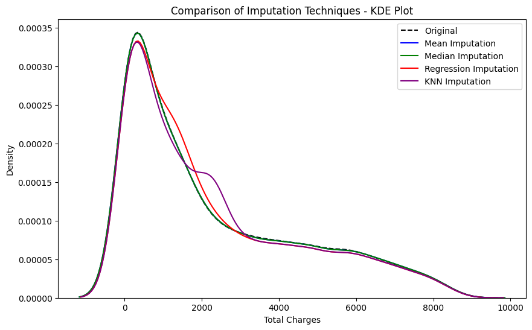

```python
#!pip install seaborn


import seaborn as sns
import matplotlib.pyplot as plt

plt.figure(figsize=(10, 6))

# Plot KDE for original and imputed values
sns.kdeplot(df["TotalCharges"], label="Original", color="black", linestyle="dashed")
sns.kdeplot(df["total_charges_mean"], label="Mean Imputation", color="blue")
sns.kdeplot(df["total_charges_median"], label="Median Imputation", color="green")
sns.kdeplot(df["total_charges_regression"], label="Regression Imputation", color="red")
sns.kdeplot(df["total_charges_knn"], label="KNN Imputation", color="purple")

plt.title("Comparison of Imputation Techniques - KDE Plot")
plt.xlabel("Total Charges")
plt.ylabel("Density")
plt.legend()
plt.show()
```

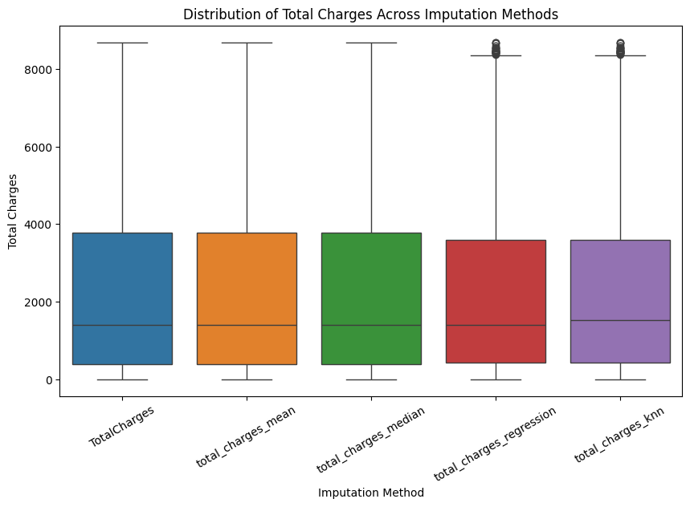

```python
plt.figure(figsize=(10, 6))
sns.boxplot(data=df[["TotalCharges", "total_charges_mean", "total_charges_median",
                      "total_charges_regression", "total_charges_knn"]])

plt.title("Distribution of Total Charges Across Imputation Methods")
plt.xlabel("Imputation Method")
plt.ylabel("Total Charges")
plt.xticks(rotation=30)
plt.show()
```

There are various imputation methods for handling missing data, and the ones we've discussed are just a few of the most common and accessible for those starting to explore the world of data analytics. For instance, mean and median imputation allows for replacing missing values with statistically representative measures, while regression imputation uses relationships between variables to estimate missing values. On the other hand, K-Nearest Neighbors (KNN) imputation relies on the similarity between observations to complete absent data. In future articles, we will delve into more advanced techniques that offer more complex and precise solutions for handling missing data, thereby providing a richer and more comprehensive understanding of this crucial topic in analytics. For now, here is a summary of some of them in case you want to research on your own.

- Advanced methods (MICE, deep learning, Bayesian inference) are useful when data is complex, high-dimensional, or when missingness is non-random.

| Technique | When to Use | Pros | Cons |
| --- | --- | --- | --- |
| **MICE (Multiple Imputation by Chained Equations)** | When uncertainty matters (e.g., statistical analysis). | Reduces bias, better estimates. | Slow, complex interpretation. |
| **Deep Learning (Autoencoders, GANs)** | Large datasets, complex relationships. | Handles non-linearity, scalable. | Needs high computation. |
| **Bayesian Imputation** | Small datasets, uncertainty estimation. | Provides probability distributions. | Computationally expensive. |

- The best method depends on the business question, computational resources, and statistical requirements.

### 2️⃣ Generate descriptive statistics and correlations

Gaining insight into the dataset's distribution enables us to uncover trends and identify potential data-related issues. Here are some initial examples of descriptive analysis you can accomplish:

#### Elemental mesures

Calculating measures of central tendency (mean, median, mode) to understand typical values, assessing variability through standard deviation and range to evaluate data dispersion.

```python
# Summary statistics for numerical variables
df.describe()
```

[output not shown]

#### Correlation Analysis

Correlation analysis helps to assess the strength and direction of the relationship between two or more variables. By calculating correlation coefficients, such as Pearson's r for linear relationships or Spearman's rank correlation for non-parametric data, you can determine whether variables move together (positive correlation) or in opposite directions (negative correlation) (values near 1 or -1 indicate strong relationships). Remember that classic correlation analysis only accepts numerical variables. However, there are methods to assess relationships involving categorical variables but we will address them in future articles.

A heatmap is a visual representation of a correlation matrix. It helps us identify:

- Which variables are strongly correlated with each other.
- Potential multicollinearity issues.
- Insights into relationships between features.

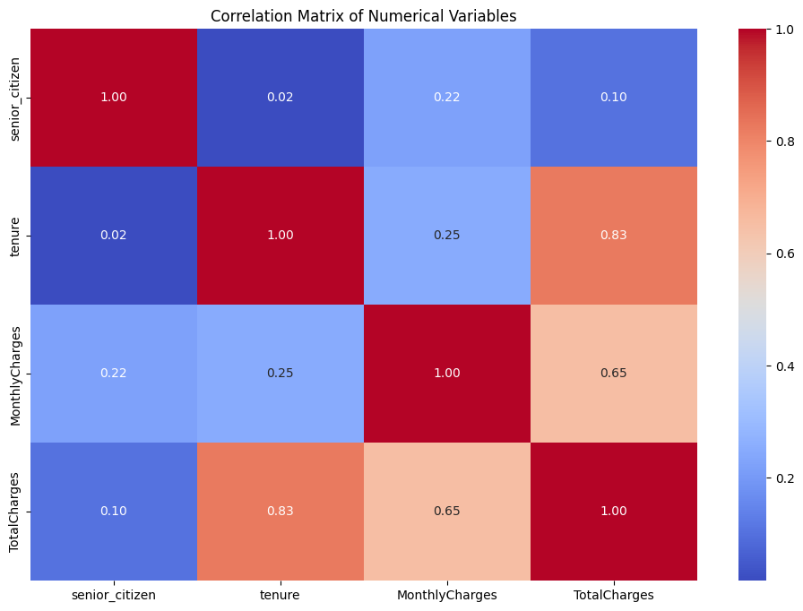

```python
import seaborn as sns
import matplotlib.pyplot as plt

# Select only numerical variables
df_numeric = df.select_dtypes(include=["number"])

# Generate the heatmap
plt.figure(figsize=(12, 8))  # Set figure size
sns.heatmap(df_numeric.corr(),  # Compute correlations
            annot=True,  # Show values inside cells
            cmap="coolwarm",  # Choose color scheme
            fmt=".2f")  # Format numbers with 2 decimals

# Add a title
plt.title("Correlation Matrix of Numerical Variables")

#plt.savefig("grafico2.png", dpi=300)  # dpi define la resolución

# Display the heatmap
plt.show()
```

#### Visualizing Churn Trends Across Segments

This bar graph shows the distribution of customers across different contract types while distinguishing between those who have churned and those who have not.

- It helps identify which contract types are more associated with customer churn.
- If month-to-month contracts have a higher proportion of churn compared to one-year or two-year contracts, this might indicate that customers with shorter commitments are more likely to leave. So, customers are more committed when they sign longer agreements.

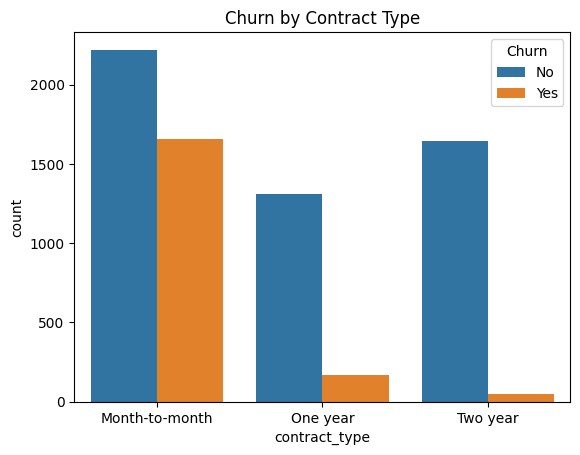

```python
df["Churn"] = df["Churn"].astype(str)  # Convert to string if needed
import seaborn as sns
import matplotlib.pyplot as plt

# Create a count plot of contract type with churn as a hue
sns.countplot(data=df, x="contract_type", hue="Churn")  # x :  count (frequency) of each contract type.
#hue="Churn" to separate customers who left (Yes) from those who stayed (No).

# Set the title of the plot
plt.title("Churn by Contract Type")

#plt.savefig("grafico1.png", dpi=300)  # dpi define la resolución

# Display the graph
plt.show()
```

### 3️⃣ Clean Data: Transform Categorical Variables and Standardizing Numerical Variables

#### Convert Binary Categorical Variables (Yes/No) to 1/0

To convert binary categorical variables (Yes/No) to numerical values (1/0), you can assign a value of 1 to "Yes" and a value of 0 to "No". However, some variables have three categories: "Yes," "No," and either "No internet service" or "No phone service." We can recategorize these two latter options as "No." Here's how you can do this:

```python
#First, make a copy so as not to affect the original dataset.
df_copy = df.copy()

# Recategorize variables
df_copy["online_security"] = df_copy["online_security"].replace({"No internet service": "No"})
df_copy["tech_support"] = df_copy["tech_support"].replace({"No internet service": "No"})
df_copy["streaming_tv"] = df_copy["streaming_tv"].replace({"No internet service": "No"})
df_copy["OnlineBackup"] = df_copy["OnlineBackup"].replace({"No internet service": "No"})
df_copy["DeviceProtection"] = df_copy["DeviceProtection"].replace({"No internet service": "No"})
df_copy["StreamingMovies"] = df_copy["StreamingMovies"].replace({"No internet service": "No"})

df_copy["MultipleLines"] = df_copy["MultipleLines"].replace({"No phone service": "No"})
```

Now, we can convert binary categorical variables (Yes/No) to numerical values (1/0):

```python
binary_cols = ["Partner", "Dependents", "PhoneService", "PaperlessBilling", "Churn","online_security",
              "tech_support","streaming_tv","OnlineBackup", "DeviceProtection", "StreamingMovies", "MultipleLines" ]
for col in binary_cols:
    df_copy[col] = df_copy[col].map({"Yes": 1, "No": 0})

df_copy.head()
```

|  | customer_id | gender | senior_citizen | Partner | Dependents | tenure | PhoneService | MultipleLines | internet_service | online_security | ... | DeviceProtection | tech_support | streaming_tv | StreamingMovies | contract_type | PaperlessBilling | payment_method | MonthlyCharges | TotalCharges | Churn |
| --- | --- | --- | --- | --- | --- | --- | --- | --- | --- | --- | --- | --- | --- | --- | --- | --- | --- | --- | --- | --- | --- |
| 0 | 7590-VHVEG | Female | 0 | 1 | 0 | 1 | 0 | 0 | DSL | 0 | ... | 0 | 0 | 0 | 0 | Month-to-month | 1 | Electronic check | 29.85 | 29.85 | 0 |
| 1 | 5575-GNVDE | Male | 0 | 0 | 0 | 34 | 1 | 0 | DSL | 1 | ... | 1 | 0 | 0 | 0 | One year | 0 | Mailed check | 56.95 | 1889.50 | 0 |
| 2 | 3668-QPYBK | Male | 0 | 0 | 0 | 2 | 1 | 0 | DSL | 1 | ... | 0 | 0 | 0 | 0 | Month-to-month | 1 | Mailed check | 53.85 | 108.15 | 1 |
| 3 | 7795-CFOCW | Male | 0 | 0 | 0 | 45 | 0 | 0 | DSL | 1 | ... | 1 | 1 | 0 | 0 | One year | 0 | Bank transfer (automatic) | 42.30 | 1840.75 | 0 |
| 4 | 9237-HQITU | Female | 0 | 0 | 0 | 2 | 1 | 0 | Fiber optic | 0 | ... | 0 | 0 | 0 | 0 | Month-to-month | 1 | Electronic check | 70.70 | 151.65 | 1 |

5 rows × 21 columns

#### Encoding for Multi-Class Categorical Variables

Two common ways to encode multi-class categorical variables are:

- **Label Encoding**: This approach assigns a unique integer to each category. For example, categories A, B, and C could be encoded as 0, 1, and 2, respectively. While this method is simple and efficient, it may introduce unintended ordinal relationships between categories, so it’s often better suited for algorithms that can handle such relationships.
- **One-Hot Encoding**: This method creates binary (0/1) columns for each category in the variable. For example, if you have a variable with three categories (A, B, C), it will create three new columns: "is_A," "is_B," and "is_C." Each row will have a 1 in the column corresponding to its category and 0s in the others.

##### Label Encoding

One trick you can use in pandas is to convert a column to a category, then use those category values for your label encoding. Then you can assign the encoded variable to a new column using the `cat.codes` accessor. An example with `Contract`, that can allow a ordinal relationship between categories.

```python
# convert a column to a category
df_copy["contract_type"] = df_copy["contract_type"].astype('category')

df_copy.dtypes
```

```
customer_id           object
gender                object
senior_citizen         int64
Partner                int64
Dependents             int64
tenure                 int64
PhoneService           int64
MultipleLines          int64
internet_service      object
online_security        int64
OnlineBackup           int64
DeviceProtection       int64
tech_support           int64
streaming_tv           int64
StreamingMovies        int64
contract_type       category
PaperlessBilling       int64
payment_method        object
MonthlyCharges       float64
TotalCharges         float64
Churn                  int64
dtype: object
```

```python
# assign the encoded variable to a new column using the cat.codes
df_copy["Contract_cat"] = df_copy["contract_type"].cat.codes
df_copy.head()
```

|  | customer_id | gender | senior_citizen | Partner | Dependents | tenure | PhoneService | MultipleLines | internet_service | online_security | ... | tech_support | streaming_tv | StreamingMovies | contract_type | PaperlessBilling | payment_method | MonthlyCharges | TotalCharges | Churn | Contract_cat |
| --- | --- | --- | --- | --- | --- | --- | --- | --- | --- | --- | --- | --- | --- | --- | --- | --- | --- | --- | --- | --- | --- |
| 0 | 7590-VHVEG | Female | 0 | 1 | 0 | 1 | 0 | 0 | DSL | 0 | ... | 0 | 0 | 0 | Month-to-month | 1 | Electronic check | 29.85 | 29.85 | 0 | 0 |
| 1 | 5575-GNVDE | Male | 0 | 0 | 0 | 34 | 1 | 0 | DSL | 1 | ... | 0 | 0 | 0 | One year | 0 | Mailed check | 56.95 | 1889.50 | 0 | 1 |
| 2 | 3668-QPYBK | Male | 0 | 0 | 0 | 2 | 1 | 0 | DSL | 1 | ... | 0 | 0 | 0 | Month-to-month | 1 | Mailed check | 53.85 | 108.15 | 1 | 0 |
| 3 | 7795-CFOCW | Male | 0 | 0 | 0 | 45 | 0 | 0 | DSL | 1 | ... | 1 | 0 | 0 | One year | 0 | Bank transfer (automatic) | 42.30 | 1840.75 | 0 | 1 |
| 4 | 9237-HQITU | Female | 0 | 0 | 0 | 2 | 1 | 0 | Fiber optic | 0 | ... | 0 | 0 | 0 | Month-to-month | 1 | Electronic check | 70.70 | 151.65 | 1 | 0 |

5 rows × 22 columns

With the following code, you can verify that the ordinal relationship has been established correctly. "Month-to-month" is assigned a value of "0," "One year" is assigned "1," and "Two years" is assigned "2".

```python
df_copy["Contract_cat"].value_counts()
#df_copy.columns
```

```
Contract_cat
0    3875
2    1695
1    1473
Name: count, dtype: int64
```

```python
df_copy["contract_type"].value_counts()
```

```
contract_type
Month-to-month    3875
Two year          1695
One year          1473
Name: count, dtype: int64
```

##### One Hot Encoding

A common alternative approach to the "Label Encoding" is called "one hot encoding". The basic strategy is to convert each category value into a new column and assigns a 1 or 0 (True/False) value to the column. This has the benefit of not weighting a value improperly but does have the downside of adding more columns to the data set.

Pandas supports this feature using get_dummies. This function is named this way because it creates dummy/indicator variables (1 or 0). Let's review the code:

This function is powerful because you can pass as many category columns as you would like and choose how to label the columns using prefix . Proper naming will make the rest of the analysis just a little bit easier.

```python
 df_copy = pd.get_dummies(df_copy, columns=["gender", "payment_method",
                                           "internet_service"],
                    prefix=["gen", "pay", "int"],
                    drop_first=True)
```

```python
# Identify boolean columns
bool_cols = df_copy.select_dtypes(include=["bool"]).columns

# Convert boolean columns to integers (0 and 1)
df_copy[bool_cols] = df_copy[bool_cols].astype(int)

df_copy.head()
```

|  | customer_id | senior_citizen | Partner | Dependents | tenure | PhoneService | MultipleLines | online_security | OnlineBackup | DeviceProtection | ... | MonthlyCharges | TotalCharges | Churn | Contract_cat | gen_Male | pay_Credit card (automatic) | pay_Electronic check | pay_Mailed check | int_Fiber optic | int_No |
| --- | --- | --- | --- | --- | --- | --- | --- | --- | --- | --- | --- | --- | --- | --- | --- | --- | --- | --- | --- | --- | --- |
| 0 | 7590-VHVEG | 0 | 1 | 0 | 1 | 0 | 0 | 0 | 1 | 0 | ... | 29.85 | 29.85 | 0 | 0 | 0 | 0 | 1 | 0 | 0 | 0 |
| 1 | 5575-GNVDE | 0 | 0 | 0 | 34 | 1 | 0 | 1 | 0 | 1 | ... | 56.95 | 1889.50 | 0 | 1 | 1 | 0 | 0 | 1 | 0 | 0 |
| 2 | 3668-QPYBK | 0 | 0 | 0 | 2 | 1 | 0 | 1 | 1 | 0 | ... | 53.85 | 108.15 | 1 | 0 | 1 | 0 | 0 | 1 | 0 | 0 |
| 3 | 7795-CFOCW | 0 | 0 | 0 | 45 | 0 | 0 | 1 | 0 | 1 | ... | 42.30 | 1840.75 | 0 | 1 | 1 | 0 | 0 | 0 | 0 | 0 |
| 4 | 9237-HQITU | 0 | 0 | 0 | 2 | 1 | 0 | 0 | 0 | 0 | ... | 70.70 | 151.65 | 1 | 0 | 0 | 0 | 1 | 0 | 1 | 0 |

5 rows × 25 columns

#### Standardizing Numerical Variables

Machine learning models, particularly Logistic Regression and XGBoost, tend to perform better when numerical variables are scaled. Scaling ensures that all features contribute equally to the model, enhancing its accuracy and efficiency.

##### Why Do We Need Feature Scaling?

- Prevents Large-Scale Features from Dominating: Some models (e.g., Logistic Regression) use gradient-based optimization. If features have different scales, the model may give more importance to larger values, leading to biased results.
- Improves Model Convergence: Algorithms like Gradient Descent converge faster when features are scaled.
- Enhances Distance-Based Models: Methods like K-Nearest Neighbors (KNN) and Principal Component Analysis (PCA) rely on distance calculations, which are sensitive to differences in scale.
- Ensures Consistent Weighting: Scaling ensures that features are treated equally, improving model stability.

In this guide, we use Standardization (Z-Score Normalization) because it is widely used in classification models like Logistic Regression and XGBoost.

```python
###Let's keep only the transformed variables and numeric variables.
# Select only numerical variables
df_copy_numeric = df_copy.select_dtypes(include=["number"])
#df_copy_numeric.columns
#df_copy_numeric.dtypes

from sklearn.preprocessing import StandardScaler

# Select numerical features to scale
num_features = ["tenure", "MonthlyCharges", "TotalCharges"]

# Initialize the scaler
scaler = StandardScaler()

# Apply scaling to the numerical columns
df_copy_numeric[num_features] = scaler.fit_transform(df_copy_numeric[num_features])

# Check transformed values
df_copy_numeric.head()
```

|  | senior_citizen | Partner | Dependents | tenure | PhoneService | MultipleLines | online_security | OnlineBackup | DeviceProtection | tech_support | ... | MonthlyCharges | TotalCharges | Churn | Contract_cat | gen_Male | pay_Credit card (automatic) | pay_Electronic check | pay_Mailed check | int_Fiber optic | int_No |
| --- | --- | --- | --- | --- | --- | --- | --- | --- | --- | --- | --- | --- | --- | --- | --- | --- | --- | --- | --- | --- | --- |
| 0 | 0 | 1 | 0 | -1.277445 | 0 | 0 | 0 | 1 | 0 | 0 | ... | -1.160323 | -0.992611 | 0 | 0 | 0 | 0 | 1 | 0 | 0 | 0 |
| 1 | 0 | 0 | 0 | 0.066327 | 1 | 0 | 1 | 0 | 1 | 0 | ... | -0.259629 | -0.172165 | 0 | 1 | 1 | 0 | 0 | 1 | 0 | 0 |
| 2 | 0 | 0 | 0 | -1.236724 | 1 | 0 | 1 | 1 | 0 | 0 | ... | -0.362660 | -0.958066 | 1 | 0 | 1 | 0 | 0 | 1 | 0 | 0 |
| 3 | 0 | 0 | 0 | 0.514251 | 0 | 0 | 1 | 0 | 1 | 1 | ... | -0.746535 | -0.193672 | 0 | 1 | 1 | 0 | 0 | 0 | 0 | 0 |
| 4 | 0 | 0 | 0 | -1.236724 | 1 | 0 | 0 | 0 | 0 | 0 | ... | 0.197365 | -0.938874 | 1 | 0 | 0 | 0 | 1 | 0 | 1 | 0 |

5 rows × 23 columns

### 4️⃣ Perform In-Depth Exploratory Analysis: Identify Churn Patterns

Now we can analyze patterns in customer churn.

#### Analyze Churn by Numerical Variables

##### Example: Distribution of Tenure by Churn

We analyze the distribution of tenure (customer duration) in each category of Churn. What do you see?

Interpretation:

- Customers who leave (churn) have shorter tenure, meaning they tend to leave early.
- Customers with long tenure are more likely to stay.

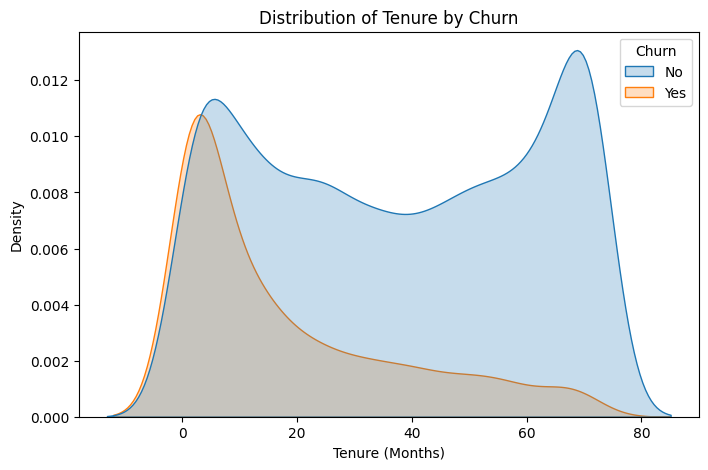

```python
#Example: Distribution of Tenure by Churn
plt.figure(figsize=(8, 5))
sns.kdeplot(data=df, x="tenure", hue="Churn", fill=True)
plt.title("Distribution of Tenure by Churn")
plt.xlabel("Tenure (Months)")

#plt.savefig("grafico3.png", dpi=300)  # Guardar imagen en alta calidad

plt.show()
```

##### Example: Boxplot of Total Charges by Churn

Interpretation:

- Churned customers often have lower total charges, meaning they may be new or lower-paying customers.

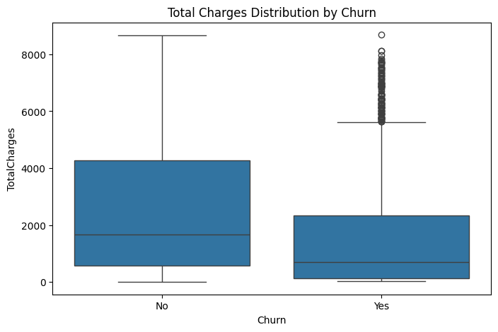

```python
plt.figure(figsize=(8, 5))
sns.boxplot(data=df, x="Churn", y="TotalCharges")
plt.title("Total Charges Distribution by Churn")
plt.show()
```

##### Example: Boxplot of Monthly Charges by Churn

Interpretation:

- Churned customers frequently incur higher monthly charges, which could be a contributing factor to their decision to leave.

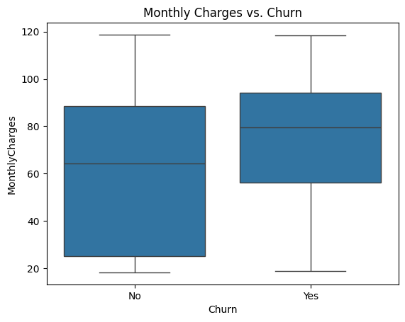

```python
sns.boxplot(data=df, x="Churn", y="MonthlyCharges")
plt.title("Monthly Charges vs. Churn")
plt.savefig("grafico4.png", dpi=300)  # Guardar imagen en alta calidad
plt.show()
```

##### Correlation Between Features and Churn

Interpretation:

- Tenure has a negative correlation with churn (longer tenure = lower churn).
- Monthly charges may have a slight positive correlation with churn, meaning high-paying customers might leave faster.

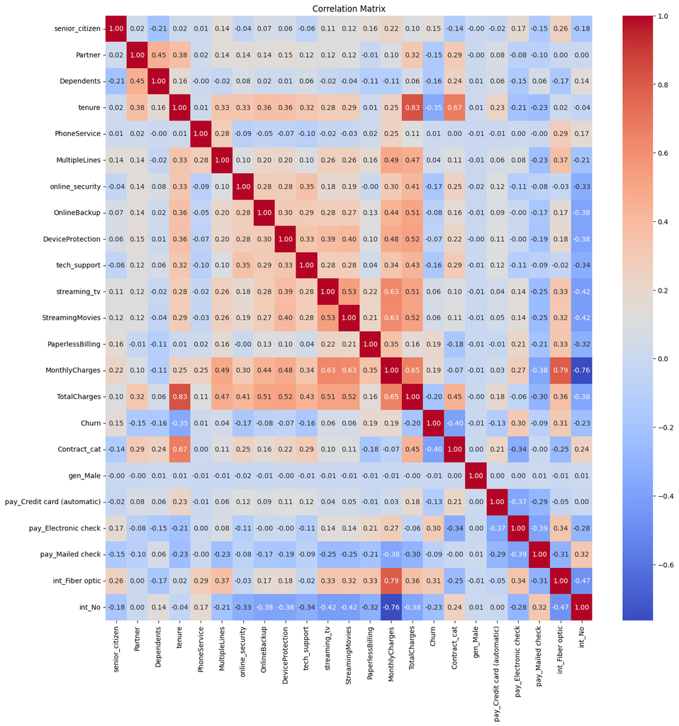

```python
import seaborn as sns
import matplotlib.pyplot as plt


# Generate the heatmap
plt.figure(figsize=(16, 16))  # Set figure size
sns.heatmap(df_copy_numeric.corr(),  # Compute correlations
            annot=True,  # Show values inside cells
            cmap="coolwarm",  # Choose color scheme
            fmt=".2f")  # Format numbers with 2 decimals

# Add a title
plt.title("Correlation Matrix")

plt.savefig("grafico5.png", dpi=300)  # Guardar imagen en alta calidad
# Display the heatmap
plt.show()
```

#### Identify Key Drivers of Churn Using Statistical Tests

We can use chi-square tests for categorical variables and t-tests for numerical variables to check for significant differences.

##### Example: Chi-Square Test for Contract Type and Churn

Interpretation:

- If p < 0.05, contract type has a significant impact on churn.

```python
from scipy.stats import chi2_contingency

contingency_table = pd.crosstab(df["contract_type"], df["Churn"])
chi2, p, dof, expected = chi2_contingency(contingency_table)

print(f"Chi-Square Test: {chi2}")
print(f"P-value: {p}")
```

```
Chi-Square Test: 1184.5965720837926
P-value: 5.863038300673391e-258
```

##### Example: T-Test for Tenure and Churn

Interpretation:

- If p < 0.05, tenure significantly impacts churn.

```python
from scipy.stats import ttest_ind

churned = df[df["Churn"] == "Yes"]["tenure"]
not_churned = df[df["Churn"] == "No"]["tenure"]

t_stat, p_value = ttest_ind(churned, not_churned, equal_var=False)
print(f"T-Test Statistic: {t_stat}, P-value: {p_value}")
```

```
T-Test Statistic: -34.823818696312976, P-value: 1.1954945472607151e-232
```

## Phase 3: Predictive Modeling

Now, we will compare three classification models:

- Logistic Regression – A baseline model for churn prediction.
- Random Forest – A powerful tree-based model.
- XGBoost – A gradient boosting algorithm for optimized performance.

### 1️⃣ Splitting the Data into Train and Test Sets

Before training a machine learning model, we first split the dataset into at least two parts: a training set and a validation or test set. The training set is then used to train the model, while the validation or test set is reserved for evaluating its performance. This process ensures that we can assess how well the model generalizes to unseen data.

- Training Set (Typically 70-80%): Used to train the model and learn patterns from the data.
- Test Set (Typically 20-30%): Used to evaluate the model's performance on unseen data, ensuring it generalizes well.

**Key Reasons for Splitting the Data:**

- ✅ Prevents overfitting (when a model memorizes training data but fails on new data).
- ✅ Provides an objective evaluation of the model before deploying it.
- ✅ Ensures the model is tested on data it has never seen before.

```python
from sklearn.model_selection import train_test_split

# Define features (X) and target variable (y)
X = df_copy_numeric.drop(columns=["Churn"])  # Features
y = df_copy_numeric["Churn"]  # Target variable

# Split into training (80%) and testing (20%) sets
X_train, X_test, y_train, y_test = train_test_split(X, y, test_size=0.2, random_state=42)

print(f"Training samples: {X_train.shape[0]}, Testing samples: {X_test.shape[0]}")
```

```
Training samples: 5634, Testing samples: 1409
```

**Alternative Splitting Strategies:**

- 70-30 Split: More test data is useful if you have a large dataset.
- Stratified Splitting: Ensures the train and test sets have a similar proportion of classes (important for imbalanced datasets).
- Cross-Validation: Instead of a single split, the data is divided into multiple training and validation sets for more robust evaluation.

### 2️⃣ Train Logistic Regression Model

Logistic Regression is a simple yet powerful classification algorithm that helps predict binary outcomes (e.g., churn: Yes/No). It models the probability of an event occurring based on input features.

**What Are We Looking For?**

- ✅ Understanding Feature Influence: How different factors impact churn probability.
- ✅ Predicting Customer Churn: Estimating whether a customer is likely to leave.
- ✅ Interpretable Coefficients: Unlike complex models, Logistic Regression provides insights into which variables influence churn the most.

```python
from sklearn.linear_model import LogisticRegression
from sklearn.metrics import classification_report, accuracy_score

# Initialize and train the model
log_reg = LogisticRegression()
log_reg.fit(X_train, y_train)

# Make predictions
y_pred = log_reg.predict(X_test)
```

#### How Do We Analyze the Results?

To evaluate the results, we need to calculate some complementary statistics.

- The ROC-AUC score (0.86) suggests that the model has a good ability to separate churn vs. non-churn customers.
- The high accuracy (0.82) is promising, but accuracy alone can be misleading if the dataset is imbalanced.
- The precision (0.69) indicates that when the model predicts churn, it is right 69% of the time.
- The recall (0.60) shows that the model captures 60% of actual churn cases. If identifying churn cases is the priority, recall should be improved.
- The F1-score (0.64) suggests a fair balance between precision and recall.

| Metric | Score | Interpretation |
| --- | --- | --- |
| **Accuracy** | 0.82 | 82% of total predictions are correct. |
| **Precision** | 0.69 | When the model predicts churn, it is correct 69% of the time. |
| **Recall** | 0.60 | The model identifies 60% of actual churn cases. |
| **F1-score** | 0.64 | A balance between precision and recall. |
| **ROC-AUC** | 0.86 | The model performs well in distinguishing between churn and non-churn customers. |

```python
# Evaluate performance
print("Accuracy:", accuracy_score(y_test, y_pred))
print(classification_report(y_test, y_pred))
```

```
Accuracy: 0.8211497515968772
              precision    recall  f1-score   support

           0       0.86      0.90      0.88      1036
           1       0.69      0.60      0.64       373

    accuracy                           0.82      1409
   macro avg       0.77      0.75      0.76      1409
weighted avg       0.82      0.82      0.82      1409
```

```python
from sklearn.metrics import precision_score

precision = precision_score(y_test, y_pred)
print("Precision:", precision)
```

[output not shown]

```python
from sklearn.metrics import recall_score

recall = recall_score(y_test, y_pred)
print("Recall:", recall)
```

[output not shown]

```python
from sklearn.metrics import f1_score

f1 = f1_score(y_test, y_pred)
print("F1-score:", f1)
```

[output not shown]

```python
from sklearn.metrics import roc_auc_score

roc_auc = roc_auc_score(y_test, log_reg.predict_proba(X_test)[:, 1])
print("ROC-AUC Score:", roc_auc)
```

```
ROC-AUC Score: 0.862273178962187
```

#### Interpret Model results (Feature Impact on Churn)

In logistic regression, interpreting coefficients is not as straightforward as in linear regression. Here, we explain three common ways to analyze feature importance and their impact on churn probability. Review the differences to understand their implications:

*Interpret Model Coefficients (Feature Impact on Churn)*

Logistic regression coefficients indicate how each variable affects the probability of churn. This represents the change in log-odds of churn when the feature increases by one unit, holding all else constant. A positive coefficient means a higher likelihood of churn; however, the logit scale is not intuitive for direct interpretation. We can extract and interpret the sign of the coefficient, which refers to the direction of the effect, but we can't make any conclusions about the amount of change.

- Positive coefficient → Increases churn probability.
- Negative coefficient → Reduces churn probability.

```python
coefficients = pd.DataFrame({"Feature": X_train.columns, "Coefficient": log_reg.coef_[0]})
coefficients = coefficients.sort_values(by="Coefficient", ascending=False)
#print(coefficients)
```

Here are some key results derived from the interpretation of the coefficients:

| **Feature** | **Logit Coefficient** | **Interpretation** |
| --- | --- | --- |
| **Tenure** | -1.349 | Longer tenure strongly reduces churn likelihood. |
| **Fiber Optic** | 0.869 | Fiber optic users have a higher risk of churn. |
| **Electronic Check** | 0.319 | Customers paying via electronic check are more likely to churn. |
| **Contract Type** | -0.697 | Long-term contracts significantly decrease churn risk. |
| **Streaming TV** | 0.221 | Customers with streaming TV are slightly more likely to churn. |
| **Streaming Movies** | 0.322 | Customers with streaming movies have a slightly higher risk of churn. |
| **Paperless Billing** | 0.334 | Paperless billing users are more prone to churn. |
| **Online Security** | -0.422 | Customers with online security tend to stay longer. |
| **Tech Support** | -0.343 | Customers with tech support are less likely to churn. |

*Odds Ratio (OR) – Easier Interpretation*

The odds ratio is calculated by exponentiating the logit coefficient (`OR = exp(coefficient`)). It represents how much more (or less) likely a customer is to churn based on that feature. OR allows for easier business decisions by expressing impact in terms of likelihood, but it does not measure the direct probability of churn.

Here’s how to interpret the Odds Ratio (OR) based on its value:

- OR = 1 → The feature has no effect on churn.
- OR > 1 → The feature increases churn risk.
- OR < 1 → The feature reduces churn risk.

```python
import numpy as np
import pandas as pd

# Get coefficients from logistic regression
coefficients = pd.DataFrame({"Feature": X_train.columns, "Logit Coefficient": log_reg.coef_[0]})

# Compute Odds Ratio (OR)
coefficients["Odds Ratio"] = np.exp(coefficients["Logit Coefficient"])

# Sort by impact
coefficients = coefficients.sort_values(by="Odds Ratio", ascending=False)
#print(coefficients)
```

Here are some key results derived from the interpretation of the OR:

| **Feature** | **Odds Ratio (OR)** | **Interpretation** |
| --- | --- | --- |
| **Tenure** | 0.259 | Customers with longer tenure are **3.86 times less likely** to churn. |
| **Fiber Optic** | 2.385 | Fiber optic users are **2.38 times more likely** to churn. |
| **Electronic Check** | 1.376 | Customers paying via electronic check are **1.38 times more likely** to churn. |
| **Contract Type** | 0.497 | Customers with long-term contracts are **2 times less likely** to churn. |
| **Streaming TV** | 1.247 | Customers with streaming TV are **1.25 times more likely** to churn. |
| **Streaming Movies** | 1.379 | Customers with streaming movies are **1.38 times more likely** to churn. |
| **Paperless Billing** | 1.396 | Customers with paperless billing are **1.40 times more likely** to churn. |
| **Online Security** | 0.656 | Customers with online security are **1.52 times less likely** to churn. |
| **Tech Support** | 0.710 | Customers with tech support are **1.41 times less likely** to churn. |

*Marginal Effect – Direct Probability Change*

The marginal effect measures the actual change in churn probability for a small increase in a feature, calculated at the average customer characteristics. They provide an intuitive, percentage-based impact, making them the most useful for direct business decisions.

To obtain marginal effects, we use `statsmodels`, which evaluates how much the actual probability of churn changes with each variable.

```python
#!pip install statsmodels

import statsmodels.api as sm

# Refit the logistic model using statsmodels
X_train_sm = sm.add_constant(X_train)  # Add intercept
logit_model = sm.Logit(y_train, X_train_sm)
result = logit_model.fit()

# Compute marginal effects
marginal_effects = result.get_margeff()
#print(marginal_effects.summary())
```

Here are some key results derived from the interpretation of the Marginal effects:

[output not shown]

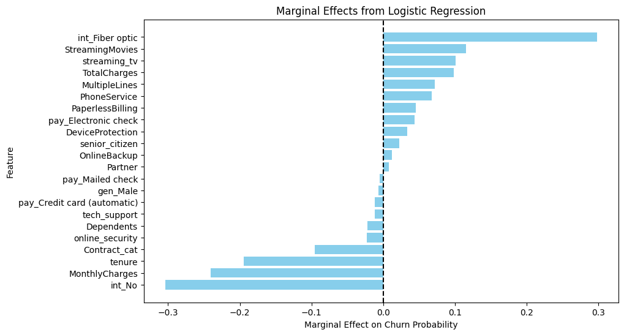

```python
import pandas as pd
import matplotlib.pyplot as plt

# Extract marginal effects values
marginal_effects_df = pd.DataFrame({
    "Feature": X_train.columns,  # Get feature names
    "Marginal Effect": marginal_effects.margeff  # Get marginal effects
})

# Sort features by absolute effect size
marginal_effects_df = marginal_effects_df.sort_values(by="Marginal Effect", ascending=False)

# Plot
plt.figure(figsize=(10, 6))
plt.barh(marginal_effects_df["Feature"], marginal_effects_df["Marginal Effect"], color="skyblue")
plt.axvline(x=0, color="black", linestyle="--")  # Reference line at 0
plt.xlabel("Marginal Effect on Churn Probability")
plt.ylabel("Feature")
plt.title("Marginal Effects from Logistic Regression")
plt.gca().invert_yaxis()  # Invert to show highest impact at the top

plt.savefig("grafico6.png", dpi=300)  # Guardar imagen en alta calidad
plt.show()
```

#### Calculate Churn Probability for Each Customer

Logistic regression outputs probabilities, which help classify risk levels. This will give you the proportion of customers who are at high risk of churn.

- If the percentage is too high, the company should prioritize customer retention strategies like personalized offers or loyalty programs.
- If it's low, the company can focus on preventative measures for medium-risk customers.

Interpretation:

- Churn Probability > 0.7 → High-risk customers → Proactively offer retention incentives.
- Churn Probability 0.3 - 0.7 → Medium risk → Personalized outreach.
- Churn Probability < 0.3 → Low risk → Focus on long-term engagement strategies.

```python
# Predict churn probabilities
churn_probs = log_reg.predict_proba(X_test)[:, 1]

# Define high-risk threshold (e.g., 0.7)
high_risk_threshold = 0.7

# Count high-risk customers
num_high_risk = sum(churn_probs > high_risk_threshold)

# Calculate percentage of high-risk customers
percent_high_risk = (num_high_risk / len(y_test)) * 100


print(f"Percentage of high-risk customers (probability > {high_risk_threshold}): {percent_high_risk:.2f}%")
```

```
Percentage of high-risk customers (probability > 0.7): 6.53%
```

A churn risk of **6.53%** means that around 6.5 out of every 100 customers are at high risk of leaving.

Interpretation & Business Implications:

- While this percentage may not seem high, losing even a small portion of customers can have a significant financial impact.
- The company should identify common characteristics of high-risk customers and target retention efforts accordingly.
- Strategies like personalized discounts, better customer support, or loyalty programs can help reduce churn.
- Additionally, monitoring medium-risk customers could be valuable, as they may transition to high risk over time.

#### Analyze Predictions (Who Is Misclassified?)

When analyzing model performance, it's essential to evaluate misclassifications, particularly False Positives (FP) and False Negatives (FN):

- False Positives (FP) – Customers Predicted to Churn but Stay: The company might unnecessarily offer retention incentives to these customers, increasing costs. So, they must use customer engagement data to refine the model and avoid misclassifying loyal customers as at risk.
- False Negatives (FN) – Customers Predicted to Stay but Actually Churn: These are the most costly errors because they represent missed opportunities for retention. Consider lowering the decision threshold to capture more high-risk customers, even if it slightly increases FP.

```python
from sklearn.metrics import confusion_matrix

y_pred = log_reg.predict(X_test)  # Generates binary predictions (0 or 1)

# Generate confusion matrix
tn, fp, fn, tp = confusion_matrix(y_test, y_pred).ravel()

# Calculate percentages
fpr = (fp / (fp + tn)) * 100  # False Positive Rate (%)
fnr = (fn / (fn + tp)) * 100  # False Negative Rate (%)

# Print results
print(f"False Positive Rate (FPR): {fpr:.2f}%")
print(f"False Negative Rate (FNR): {fnr:.2f}%")
```

```
False Positive Rate (FPR): 9.94%
False Negative Rate (FNR): 39.95%
```

False Positive Rate (FPR) = 9.94%

- About 1 in 10 non-churners were incorrectly classified as churners.
- This means some loyal customers might be mistakenly targeted for retention campaigns, leading to unnecessary costs.

False Negative Rate (FNR) = 39.95%

- Nearly 40% of actual churners were not identified by the model.
- This is concerning because these customers will leave without intervention.
- Some strategic actions include: Adjust the probability threshold (e.g., lower than 0.5) to capture more churners, use more predictive features (e.g., engagement metrics) or try a more complex model like XGBoost for better detection.

#### Let's set a new threshold

By default, when you use `log_reg.predict(X_test)` as before, Scikit-learn applies a threshold of 0.5. Now, we will try a different threshold of 0.4. You can also try several thresholds on your own.

```python
from sklearn.metrics import confusion_matrix

# Set a new threshold (try 0.4 or 0.3 instead of 0.5)
new_threshold = 0.4
y_pred_adjusted = (churn_probs >= new_threshold).astype(int)

# Confusion matrix
tn, fp, fn, tp = confusion_matrix(y_test, y_pred_adjusted).ravel()

# Recalculate FPR and FNR
fpr_adjusted = fp / (fp + tn)  # False Positive Rate
fnr_adjusted = fn / (fn + tp)  # False Negative Rate

# Convert to percentage
fpr_adjusted_pct = round(fpr_adjusted * 100, 2)
fnr_adjusted_pct = round(fnr_adjusted * 100, 2)

print(f"New Threshold: {new_threshold}")
print(f"False Positive Rate (FPR): {fpr_adjusted_pct}%")
print(f"False Negative Rate (FNR): {fnr_adjusted_pct}%")
```

```
New Threshold: 0.4
False Positive Rate (FPR): 16.51%
False Negative Rate (FNR): 30.03%
```

**📊 Threshold comparison: 0.5 vs. 0.4**

| Threshold | False Positive Rate (FPR) | False Negative Rate (FNR) |
| --- | --- | --- |
| **0.5 (Default)** | **9.94%** (Lower) | **39.95%** (Higher) |
| **0.4 (Adjusted)** | **16.51%** (Higher) | **30.03%** (Lower) |

What Changed?

- Lowering the threshold to 0.4 reduced False Negatives (39.95% → 30.03%), meaning more actual churners were detected. ✅
- However, it increased False Positives (9.94% → 16.51%), meaning more non-churners were incorrectly classified as churners. ⚠️

Key Takeaway:

Lowering the threshold makes the model more sensitive to churn but increases false alarms. This trade-off depends on business priorities:

- If missing churners is more costly, a lower threshold (e.g., 0.4) is preferable.
- If incorrectly flagging loyal customers is more costly, keeping 0.5 or a higher threshold might be better.

**Next Steps: Exploring More Powerful Models**

While **Logistic Regression** offers a straightforward and interpretable approach, there is room for improvement in predictive performance. To enhance accuracy and reduce misclassification, we will explore more advanced models:

- **Random Forest:** This model captures complex interactions between variables and is less prone to overfitting by averaging multiple decision trees.
- **XGBoost:** A high-performance gradient boosting algorithm that is widely used in churn prediction due to its ability to optimize errors and improve predictive power.

Next, we will implement and compare these models to see how they perform in identifying customers at risk of churn. 🚀

### 3️⃣ Train Random Forest Model

Random Forest is an ensemble learning method that builds multiple decision trees and combines their predictions to improve accuracy and reduce overfitting. Each tree is trained on a random subset of data, and the final prediction is made by averaging (for regression) or majority voting (for classification).

Why use Random Forest?

- ✔️ Handles both categorical and numerical data
- ✔️ Reduces overfitting by averaging multiple trees
- ✔️ Captures complex patterns in the data

key parameters:

- `n_estimators=100`: The number of trees in the forest. A higher value improves model stability but increases training time.
- `random_state=42`: Sets the random seed for reproducibility.

Let’s train the model and analyze its results!

```python
from sklearn.ensemble import RandomForestClassifier
from sklearn.metrics import accuracy_score, classification_report, confusion_matrix

# Initialize and train the model
rf_model = RandomForestClassifier(n_estimators=100, random_state=42)
rf_model.fit(X_train, y_train)

# Make predictions
y_pred_rf = rf_model.predict(X_test)
```

In our model, we set `n_estimators=100`, meaning we train 100 decision trees and combine their results for a more stable and accurate prediction.

- More trees reduce variance (less overfitting).
- The model becomes more robust to noise in the data.
- Beyond a certain point, adding more trees gives diminishing returns in accuracy but increases computation time.

Other Options for `n_estimators`:

- Fewer Trees (e.g., 10-50): Faster training but might not capture enough patterns.
- More Trees (e.g., 200-500): Can slightly improve accuracy but increases computation time.

#### How Do We Analyze the Results?

As we did with the logistic regression model, we can now evaluate the results:

**Random Forest Model Performance**

[output not shown]

Insights and Interpretation:

- **The ROC-AUC score (0.839) is strong**, meaning the model distinguishes churners well, but **accuracy (79.6%) is slightly lower than logistic regression**.
- **Precision (66%) is acceptable**, but **recall (47%) is low**, meaning the model **fails to identify many churners**.
- **The model has lower recall and F1-score than logistic regression**, so it might not be the best option if the goal is to **capture as many churners as possible**.

```python
# Evaluate the model
print("Random Forest Model Performance:")
print("Accuracy:", accuracy_score(y_test, y_pred_rf))
print(classification_report(y_test, y_pred_rf))
```

```
Random Forest Model Performance:
Accuracy: 0.7955997161107168
              precision    recall  f1-score   support

           0       0.83      0.91      0.87      1036
           1       0.66      0.47      0.55       373

    accuracy                           0.80      1409
   macro avg       0.74      0.69      0.71      1409
weighted avg       0.78      0.80      0.78      1409
```

```python
from sklearn.metrics import roc_auc_score

roc_auc = roc_auc_score(y_test, rf_model.predict_proba(X_test)[:, 1])
print("ROC-AUC Score:", roc_auc)
```

```
ROC-AUC Score: 0.838737099796081
```

#### Feature Importance Analysis

Random Forest provides feature importance scores, showing which factors influence churn the most.

Random Forest automatically calculates feature importance, which tells us which factors are most influential in predicting churn. Unlike logistic regression, which provides coefficients, Random Forest ranks features based on how much they reduce impurity (error) in decision trees. Each time a decision tree splits on a variable, it reduces uncertainty (entropy). The more a feature is used for splitting, the more important it is.

[output not shown]

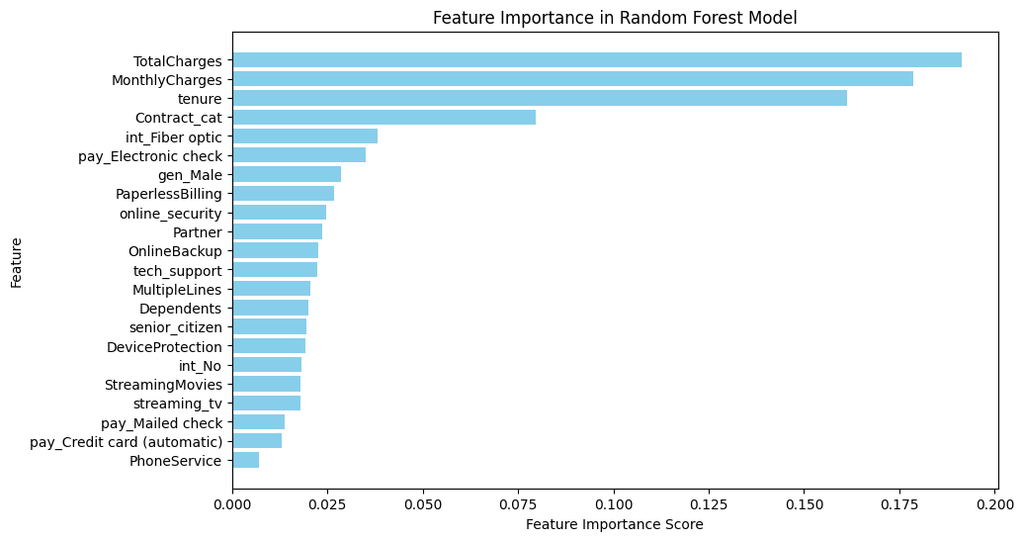

```python
import pandas as pd
import matplotlib.pyplot as plt

# Extract feature importance
feature_importance = pd.DataFrame({"Feature": X_train.columns,
                                   "Importance": rf_model.feature_importances_})
feature_importance = feature_importance.sort_values(by="Importance", ascending=False)

# Plot feature importance
plt.figure(figsize=(10, 6))
plt.barh(feature_importance["Feature"], feature_importance["Importance"], color="skyblue")
plt.xlabel("Feature Importance Score")
plt.ylabel("Feature")
plt.title("Feature Importance in Random Forest Model")
plt.gca().invert_yaxis()

plt.savefig("grafico7.png", dpi=300)  # Guardar imagen en alta calidad

plt.show()
```

#### Calculate Churn Probability for Each Customer

Random Forest also outputs probabilities, which help classify risk levels. This provides the proportion of customers who are at high risk of churn. We will use the same interpretation as we did for the logistic regression model.

- Churn Probability > 0.7 → High-risk customers → Proactively offer retention incentives.
- Churn Probability 0.3 - 0.7 → Medium risk → Personalized outreach.
- Churn Probability < 0.3 → Low risk → Focus on long-term engagement strategies.

```python
# Get churn probabilities
churn_probs_rf = rf_model.predict_proba(X_test)[:, 1]

# Define high-risk threshold (e.g., 0.7)
high_risk_threshold = 0.7

# Count high-risk customers
num_high_risk_rf = sum(churn_probs_rf > high_risk_threshold)

# Calculate percentage of high-risk customers
percent_high_risk_rf = (num_high_risk_rf / len(y_test)) * 100


print(f"Percentage of high-risk customers (probability > {high_risk_threshold}): {percent_high_risk_rf:.2f}%")
```

```
Percentage of high-risk customers (probability > 0.7): 8.87%
```

A churn risk of **8.87%** means that around almost 9 out of every 100 customers are at high risk of leaving.

Comparing the results, Logistic Regression (6.53%) identifies a smaller group of customers as high-risk, meaning it is more conservative in flagging potential churners. Random Forest (8.87%) flags more customers as high-risk, suggesting it is more sensitive to churn indicators.

#### Analyze Predictions (Who Is Misclassified?)

As we did with the logistic regression model, let's check where the model fails:

```python
# Confusion matrix
conf_matrix_rf = confusion_matrix(y_test, y_pred_rf)
TN, FP, FN, TP = conf_matrix_rf.ravel()

# Calculate error rates
FPR_rf = FP / (FP + TN)  # False Positive Rate
FNR_rf = FN / (FN + TP)  # False Negative Rate

print(f"False Positive Rate (FPR): {FPR_rf:.2%}")
print(f"False Negative Rate (FNR): {FNR_rf:.2%}")
```

```
False Positive Rate (FPR): 8.88%
False Negative Rate (FNR): 52.55%
```

Comparison of Misclassification Rates: Logistic Regression vs. Random Forest

| **Metric** | **Logistic Regression (T = 0.5)** | **Random Forest (T = 0.5)** | **Change** |
| --- | --- | --- | --- |
| **False Positive Rate (FPR)** | **9.94%** | **8.88%** | 🔽 **Better (↓1.06%)** |
| **False Negative Rate (FNR)** | **39.95%** | **52.55%** | 🔼 **Worse (↑12.6%)** |

Interpretation & Business Implications:

- **Lower FPR (False Positives)** in Random Forest means fewer loyal customers are mistakenly labeled as churners, reducing unnecessary retention efforts.
- **Higher FNR (False Negatives)** suggests Random Forest is missing more actual churners (52.55%) compared to Logistic Regression (39.95%).
- This means many customers at real risk of leaving are not being flagged, reducing the effectiveness of proactive retention strategies.

**Next Steps**

- Adjusting the threshold for Random Forest might help reduce False Negatives and better capture churners.
- Using ensemble methods (combining both models) could balance sensitivity and specificity.
- Feature engineering** (adding new variables) might improve Random Forest’s ability to distinguish churners.

Let's try adjusting the threshold.

#### Adjusting the Decision Threshold

By default, Random Forest uses a 0.5 threshold for churn predictions. We can adjust it to improve recall or precision.

```python
new_threshold = 0.4  # Lower threshold to detect more churners

# Adjust predictions
y_pred_adjusted_rf = (churn_probs_rf >= new_threshold).astype(int)

# Recalculate FPR & FNR
conf_matrix_adj = confusion_matrix(y_test, y_pred_adjusted_rf)
TN_adj, FP_adj, FN_adj, TP_adj = conf_matrix_adj.ravel()

FPR_adj = FP_adj / (FP_adj + TN_adj)
FNR_adj = FN_adj / (FN_adj + TP_adj)

print(f"New Threshold: {new_threshold}")
print(f"False Positive Rate (FPR): {FPR_adj:.2%}")
print(f"False Negative Rate (FNR): {FNR_adj:.2%}")
```

```
New Threshold: 0.4
False Positive Rate (FPR): 14.96%
False Negative Rate (FNR): 35.66%
```

**Impact of Adjusting the Decision Threshold on Misclassification Rates**

| **Model** | **Threshold** | **False Positive Rate (FPR)** | **False Negative Rate (FNR)** |
| --- | --- | --- | --- |
| **Logistic Regression** | **0.5** | 9.94% | 39.95% |
| **Logistic Regression** | **0.4** | 16.51% | 30.03% |
| **Random Forest** | **0.5** | 8.88% | 52.55% |
| **Random Forest** | **0.4** | 14.96% | 35.66% |

**Interpretation and Business Implications**

- Lowering the threshold **reduces FNR** (captures more actual churners) but **increases FPR** (more loyal customers misclassified).
- **For Logistic Regression:**
  - Lowering the threshold to **0.4** significantly improves recall (captures **more churners**, reducing FNR from **39.95% to 30.03%**).
  - However, it also increases FPR (**9.94% → 16.51%**), meaning more customers are incorrectly targeted for retention efforts.
- **For Random Forest:**
  - Reducing the threshold **substantially improves recall** (FNR **drops from 52.55% to 35.66%**), making it much better at detecting churners.
  - But FPR also rises (**8.88% → 14.96%**), leading to a higher cost of unnecessary interventions.

**Next Steps**

- The best threshold **depends on business priorities**:
  - If minimizing false negatives (churners we miss) is critical → **Lower the threshold** (0.4).
  - If avoiding false positives (targeting loyal customers) is more important → **Keep a higher threshold** (0.5).
- **A hybrid approach** could combine both models or use **personalized thresholds** based on customer segments.

### 4️⃣ Train XGBoost Model

Extreme Gradient Boosting (XGBoost) is a powerful and optimized gradient boosting algorithm widely used for predictive modeling. It builds multiple decision trees sequentially, correcting errors at each step to maximize accuracy while preventing overfitting.

**Why Use XGBoost for Churn Prediction?**

- High Predictive Power: Often outperforms traditional models like Logistic Regression and Random Forest.
- Handles Missing Values: Unlike other models, XGBoost can automatically handle missing data, reducing preprocessing efforts.
- Feature Interactions: Learns complex relationships between variables.
- Regularization: Includes L1/L2 penalties to reduce overfitting.

**Training Process** We'll train an XGBoost Classifier with a learning rate, tree depth, and regularization to optimize performance.

Key Parameters

- `n_estimators`: Number of boosting rounds (trees).
- `max_depth`: Controls the depth of each tree (prevents overfitting).
- `learning_rate`: Shrinks feature weights to improve generalization.

```python
#!pip install xgboost
from xgboost import XGBClassifier


# Initialize XGBoost model
xgb_model = XGBClassifier(n_estimators=100, max_depth=4, learning_rate=0.1, use_label_encoder=False, eval_metric="logloss")

# Train the model
xgb_model.fit(X_train, y_train)

# Make predictions
y_pred_xgb = xgb_model.predict(X_test)
```

#### How Do We Analyze the Results?

As we did with the previous models, we can now evaluate the results:

| Metric | Logistic Regression | Random Forest | XGBoost (New) |
| --- | --- | --- | --- |
| **Accuracy** | 0.821 | 0.796 | **0.809** |
| **ROC-AUC Score** | 0.862 | 0.839 | **0.860** |
| **Precision** | 0.685 | 0.660 | **0.670** |
| **Recall** | 0.601 | 0.470 | **0.550** |
| **F1-Score** | 0.640 | 0.550 | **0.600** |

Next, we will analyze **feature importance** to understand what drives churn in the XGBoost model.

```python
from sklearn.metrics import classification_report, accuracy_score, roc_auc_score

# Evaluate performance
accuracy_xgb = accuracy_score(y_test, y_pred_xgb)
roc_auc_xgb = roc_auc_score(y_test, xgb_model.predict_proba(X_test)[:, 1])

print("Accuracy:", accuracy_xgb)
print("ROC-AUC Score:", roc_auc_xgb)
print(classification_report(y_test, y_pred_xgb))
```

```
Accuracy: 0.8090844570617459
ROC-AUC Score: 0.859849700332274
              precision    recall  f1-score   support

           0       0.85      0.90      0.87      1036
           1       0.67      0.55      0.60       373

    accuracy                           0.81      1409
   macro avg       0.76      0.73      0.74      1409
weighted avg       0.80      0.81      0.80      1409
```

#### Feature Importance Analysis

XGBoost assigns importance scores to features, helping us identify the top drivers of churn.

**Feature Importance Comparison: XGBoost vs. Random Forest vs. Logistic Regression**

| Feature | XGBoost Importance | Random Forest Importance | Logistic Regression | Interpretation |
| --- | --- | --- | --- | --- |
| **Contract Type** | **0.333** | **0.080** | **OR = 0.50** (↓ churn) | The most influential factor in XGBoost. Longer contracts significantly reduce churn, aligning with the strong negative impact seen in logistic regression. |
| **Fiber Optic Internet** | **0.253** | **0.038** | **OR = 2.38** (↑ churn) | Fiber optic users have a much higher churn risk, confirmed across all models. Pricing or service dissatisfaction may be driving this trend. |
| **No Internet Service** | **0.062** | **0.018** | **OR = 0.41** (↓ churn) | Customers without internet service churn less, possibly because they subscribe to other services like phone lines. Logistic regression also confirms this protective effect. |
| **Tenure** | **0.035** | **0.161** | **Marginal Effect = -0.194** (↓ churn) | Longer tenure reduces churn risk. This effect is strongest in logistic regression and Random Forest, but less emphasized in XGBoost. |
| **Electronic Check** | **0.034** | **0.035** | **OR = 1.38** (↑ churn) | Customers paying with electronic checks are at higher churn risk, consistent across all models. This suggests financial instability or dissatisfaction. |
| **Streaming Movies** | **0.033** | **0.018** | **Marginal Effect = 0.115** (↑ churn) | Customers subscribed to streaming movies have a higher churn risk. This may indicate dissatisfaction or competition from other platforms. |
| **Tech Support** | **0.023** | **0.022** | **OR = 0.71** (↓ churn) | Customers receiving tech support are **less likely to churn**. This trend is **consistent across all models**, showing the importance of customer assistance. |
| **Online Security** | **0.021** | **0.025** | **OR = 0.66** (↓ churn) | Having online security services significantly **reduces churn**, suggesting that customers value security features. This effect aligns with logistic regression results. |

**Key Takeaways**

- **Contract type has a massive impact in XGBoost** but was less emphasized in Random Forest.
- **Fiber optic internet users are at high churn risk**, confirmed by all models. Service quality or pricing strategies should be reviewed.
- **Tenure has a much stronger effect in logistic regression and Random Forest**, emphasizing the role of long-term customer relationships
- **Electronic check payments are consistently linked to churn**, making automated payments a key intervention area.
- **Tech support and online security consistently lower churn**, meaning companies should **prioritize these services** to retain customers.

By comparing tree-based models (XGBoost & Random Forest) with logistic regression, we gain deeper insights into which factors drive churn and how to optimize customer retention strategies.

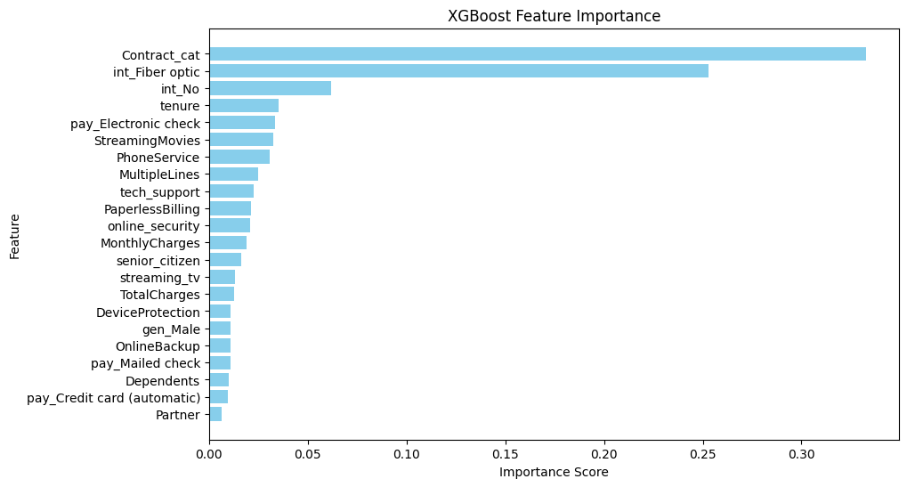

```python
import matplotlib.pyplot as plt
import pandas as pd

# Extract feature importance
feature_importance = pd.DataFrame({
    "Feature": X_train.columns,
    "Importance": xgb_model.feature_importances_
}).sort_values(by="Importance", ascending=False)

# Plot feature importance
plt.figure(figsize=(10,6))
plt.barh(feature_importance["Feature"], feature_importance["Importance"], color="skyblue")
plt.xlabel("Importance Score")
plt.ylabel("Feature")
plt.title("XGBoost Feature Importance")
plt.gca().invert_yaxis()

plt.savefig("grafico8.png", dpi=300)  # Guardar imagen en alta calidad

plt.show()
```

While XGBoost and Random Forest effectively identify the most influential factors driving churn, they do not indicate whether these factors increase or decrease churn. In contrast, logistic regression provides clear directional effects (positive or negative) through odds ratios. Therefore, combining these approaches offers a more comprehensive churn analysis—leveraging tree-based models for predictive power and feature ranking, while using logistic regression to understand the direction and magnitude of each factor’s impact. For deeper insights, **SHAP values** or **Partial Dependence Plots (PDPs)** can further clarify how features influence churn probability.

**SHAP Values (Feature Contributions to Churn Probability)**

SHAP (SHapley Additive exPlanations) values help interpret the direction and magnitude of each feature's contribution to churn probability.

**How to Interpret the SHAP Summary Plot**

- Features at the top are the most influential in predicting churn.
- Each point represents a customer, and its position on the x-axis shows how much that feature pushes churn predictions up or down.
- Red points indicate high values of the feature, while blue points indicate low values.
- Direction matters:
  - If red points are on the right → High values increase churn risk (e.g., MonthlyCharges).
  - If red points are on the left → High values reduce churn risk (e.g., Contract_cat).
  - If blue points are on the right → Low values increase churn risk (e.g., short tenure).
  - If blue points are on the left → Low values reduce churn risk (e.g., low MonthlyCharges).
- The x-axis represents SHAP values:
  - Negative values (left) → The feature decreases churn probability.
  - Positive values (right) → The feature increases churn probability.

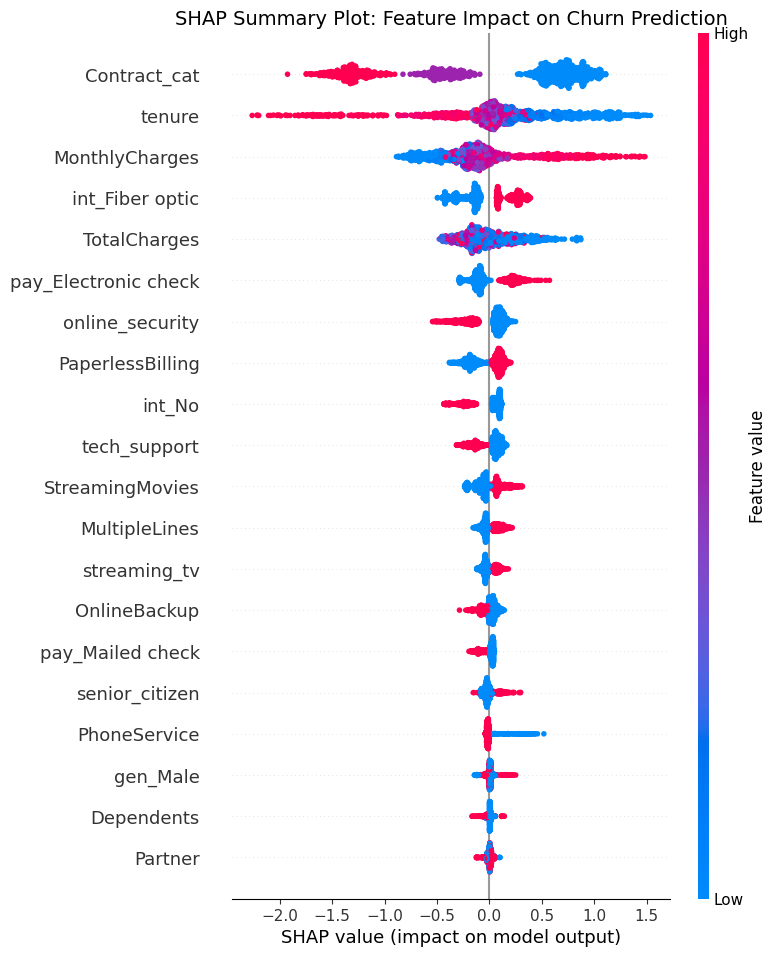

```python
#!pip install shap

import shap
import matplotlib.pyplot as plt

# Create SHAP explainer for XGBoost
explainer = shap.Explainer(xgb_model, X_test)

# Compute SHAP values
shap_values = explainer(X_test)

# Create the SHAP summary plot
plt.figure(figsize=(10, 6))
shap.summary_plot(shap_values, X_test, show=False)

# Add a title
plt.title("SHAP Summary Plot: Feature Impact on Churn Prediction", fontsize=14)

# Save the plot as a PNG file
plt.savefig("Gráfico9.png", dpi=300, bbox_inches="tight")

# Show the plot
plt.show()
```

1. Contract_cat (Contract Type)
- High values (red) represent long-term contracts (e.g., one or two years).
- Since long-term contracts reduce churn, red points appear on the left side (negative SHAP impact).
- Low values (blue) indicate month-to-month contracts, which increase churn, so blue points appear on the right (positive SHAP impact).
2. MonthlyCharges
- High values (red) mean higher monthly bills, which increase churn probability → Red points appear on the right (positive SHAP impact).
- Low values (blue) mean lower bills, which reduce churn probability → Blue points appear on the left (negative SHAP impact).

**Partial Dependence Plots (PDPs)**

Partial Dependence Plots (PDPs) show the marginal effect of a feature on the predicted churn probability while keeping other features constant. Here’s how to read the graph:

- X-axis: Represents the values of the selected feature (e.g., Monthly Charges).
- Y-axis: Shows the predicted probability of churn.
- The curve/trend: Indicates how churn probability changes as the feature increases.

Example Interpretations:

- 📈 If the PDP curve slopes upwards, higher values of the feature increase churn risk (e.g., higher Monthly Charges → more likely to churn).
- 📉 If the PDP curve slopes downwards, higher values of the feature reduce churn risk (e.g., longer tenure → lower probability of churn). Additionally, a longer contract type is associated with less churn risk.
- ↔️ A flat curve means the feature has little impact on churn.

This helps businesses identify key risk factors and adjust strategies accordingly.

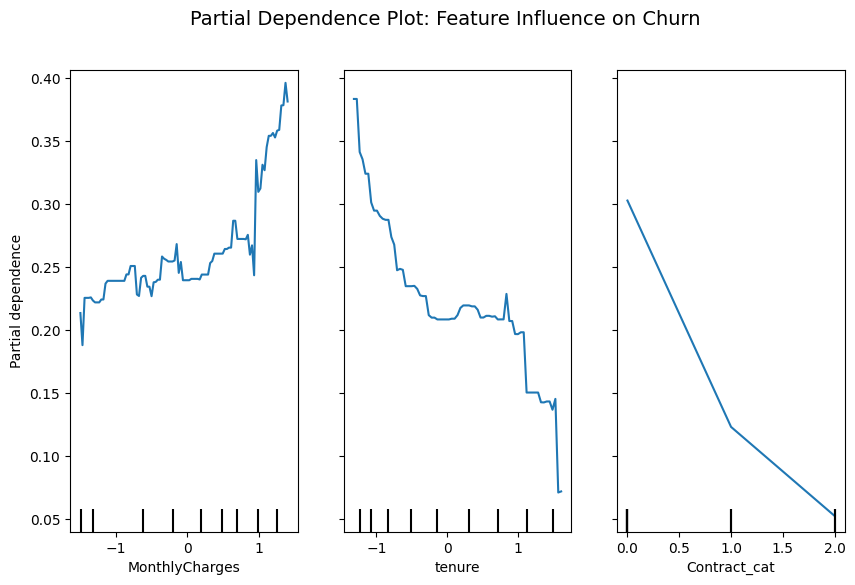

```python
from sklearn.inspection import PartialDependenceDisplay
import matplotlib.pyplot as plt

# Define the features to analyze
features = ["MonthlyCharges", "tenure", "Contract_cat"]

# Generate PDP plots
fig, ax = plt.subplots(figsize=(10, 6))
PartialDependenceDisplay.from_estimator(xgb_model, X_train, features, ax=ax)

# Add a title
plt.suptitle("Partial Dependence Plot: Feature Influence on Churn", fontsize=14)

plt.savefig("grafico10.png", dpi=300)  # Guardar imagen en alta calidad
plt.show()
```

#### Calculate Churn Probability for Each Customer

```python
# Compute churn probabilities
churn_probs_xgb = xgb_model.predict_proba(X_test)[:, 1]

# Identify high-risk customers (p > 0.7)
high_risk_xgb = (churn_probs_xgb > 0.7).mean() * 100
print(f"Percentage of high-risk customers (probability > 0.7): {high_risk_xgb:.2f}%")
```

```
Percentage of high-risk customers (probability > 0.7): 8.30%
```

| Model | % High-Risk Customers (Prob > 0.7) |
| --- | --- |
| Logistic Regression | 6.53% |
| Random Forest | 8.87% |
| XGBoost | 8.30% |

Key Takeaways:

- XGBoost identifies slightly fewer high-risk customers than Random Forest but more than Logistic Regression.
- This suggests XGBoost is more conservative than Random Forest in flagging high-risk customers.
- Businesses should prioritize retention efforts on this segment, as these customers have the highest likelihood of churning.

#### Analyze Predictions (Who Is Misclassified?)

Just like before, we analyze misclassification rates to determine how well the model differentiates churners from non-churners.

```python
from sklearn.metrics import confusion_matrix

# Compute confusion matrix
tn, fp, fn, tp = confusion_matrix(y_test, y_pred_xgb).ravel()

# Calculate FPR and FNR
fpr_xgb = fp / (fp + tn)
fnr_xgb = fn / (fn + tp)

print(f"False Positive Rate (FPR): {fpr_xgb:.2%}")
print(f"False Negative Rate (FNR): {fnr_xgb:.2%}")
```

```
False Positive Rate (FPR): 9.75%
False Negative Rate (FNR): 45.04%
```

**False Positive Rate (FPR) & False Negative Rate (FNR) Comparison**

| Model | FPR (False Positive Rate) | FNR (False Negative Rate) | Interpretation |
| --- | --- | --- | --- |
| **Logistic Regression** | **9.94%** | **39.95%** | Balanced, but misses 40% of actual churners. |
| **Random Forest** | **8.88%** | **52.55%** | Fewer false positives but struggles to identify churners. |
| **XGBoost** | **9.75%** | **45.04%** | Better recall than Random Forest, but more false positives. |

- **Random Forest has the highest FNR (52.55%)**, meaning it fails to detect more than half of the actual churners.
- **XGBoost balances FPR and FNR better than Random Forest**, making it more reliable for identifying high-risk customers.
- **Logistic Regression still has the lowest FNR (39.95%)**, meaning it captures more churners than the other models.
- If **reducing false negatives (capturing more churners)** is the priority, **Logistic Regression is the best choice**.
- If **minimizing false alarms (FPR) is the priority**, **Random Forest performs better** but at the cost of missing churners.
- **XGBoost provides a middle ground** between these two models.

#### Adjusting the Decision Threshold

By default, XGBoost classifies churn based on a 0.5 threshold. We can lower the threshold (e.g., 0.4) to capture more churners at the cost of increasing false positives.

```python
# Adjust threshold to 0.4
new_threshold = 0.4
y_pred_xgb_adjusted = (churn_probs_xgb >= new_threshold).astype(int)

# Recompute confusion matrix
tn, fp, fn, tp = confusion_matrix(y_test, y_pred_xgb_adjusted).ravel()

# Calculate new FPR and FNR
fpr_xgb_adjusted = fp / (fp + tn)
fnr_xgb_adjusted = fn / (fn + tp)

print(f"New Threshold: {new_threshold}")
print(f"False Positive Rate (FPR): {fpr_xgb_adjusted:.2%}")
print(f"False Negative Rate (FNR): {fnr_xgb_adjusted:.2%}")
```

```
New Threshold: 0.4
False Positive Rate (FPR): 15.15%
False Negative Rate (FNR): 29.76%
```

**Effect of Adjusting the Decision Threshold (0.4) on FPR & FNR**

[output not shown]

The **trade-off is clear**: **lowering the threshold captures more churners but increases false positives**, meaning more customers who wouldn’t have churned might be misclassified.

## Final Comparison: Logistic Regression vs. Random Forest vs. XGBoost

### Model performance summary

[output not shown]

### Confusion Matrices (Comparison at Default Threshold 0.5)

[output not shown]

- Logistic Regression has the fewest false negatives (149 missed churners), making it the best at identifying churners.
- Random Forest struggles the most with false negatives (196), meaning it often fails to detect actual churners.
- XGBoost provides a more balanced performance between false positives and false negatives compared to Random Forest.

### Precision-Recall Curve and ROC-AUC Curve

**Plot 1: Precision-Recall Curve Comparison**

What does this graph represent?

- The x-axis (Recall) represents how many actual churners (positives) the model correctly identifies.
- The y-axis (Precision) represents how many of the predicted churners are actually correct.

A perfect model would have both high recall and high precision, meaning it identifies all churners without misclassifying non-churners.

- At low recall values (left side of the curve):
  - The model is making very selective predictions, only classifying the most confident cases as churn.
  - Since it’s very selective, the precision is high (most of the predicted churners are actually churners).
- As recall increases (moving right on the curve):
  - The model expands its predictions to include more churners, but it also starts misclassifying more non-churners as churners.
  - This leads to a drop in precision because a higher percentage of predicted churners are actually false positives.

There is always a trade-off: Improving recall means catching more churners, but at the cost of more false positives, lowering precision.

- The steepness of the decline in precision varies between models:
  - XGBoost maintains higher precision for longer before dropping, suggesting better overall performance.
  - Random Forest drops faster, meaning it struggles more with precision at higher recall levels.
  - Logistic Regression has a balanced decline, staying competitive across recall values.

This behavior is why choosing the right threshold is crucial—it balances precision and recall to match the business goals (e.g., minimizing false positives vs. maximizing true churn detection)

- Higher AUC-PR = Better Performance
  - XGBoost has the highest AUC-PR (0.70), meaning it generally balances precision and recall better than the other models.
  - Logistic Regression is close behind, showing it is also a strong model.
  - Random Forest has the lowest AUC-PR, meaning it struggles more with precision-recall tradeoffs.

**Plot 2: ROC-AUC Curve Comparison**

The ROC-AUC (Receiver Operating Characteristic - Area Under the Curve) measures a model’s ability to distinguish between churners and non-churners. A higher value means the model is better at ranking positive cases (churn) higher than negative cases (non-churn).

What does this graph represent?

- The x-axis (False Positive Rate - FPR) represents the percentage of non-churners that were misclassified as churners.
- The y-axis (True Positive Rate - TPR or Recall) represents the percentage of churners correctly identified.
- The diagonal line represents a random classifier (50% chance).

How to Interpret the Shape of the Curves?

- The closer a model's curve is to the top-left corner, the better it is at distinguishing between churners and non-churners.
- If a model follows the diagonal line, it has no predictive power (random guessing).

Higher AUC-ROC = Better Model Performance

- Logistic Regression & XGBoost perform similarly (AUC = 0.86), meaning they are equally effective at distinguishing churners from non-churners.
- Random Forest has a slightly lower AUC (0.84), indicating it might struggle slightly more with ranking true churners correctly.
- Since all models have AUC values above 0.80, they all show strong discriminatory power, but Logistic Regression and XGBoost are slightly superior in ranking customers by churn risk.

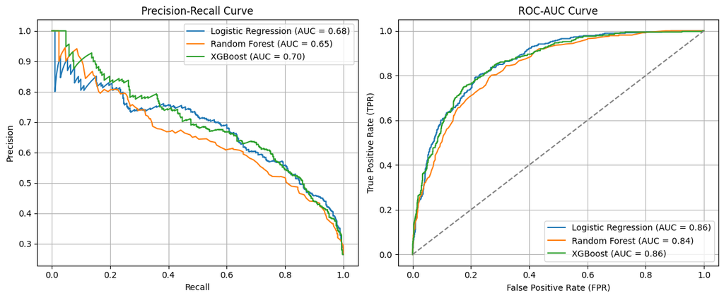

```python
import matplotlib.pyplot as plt
from sklearn.metrics import precision_recall_curve, roc_curve, auc

# Lista de modelos entrenados y etiquetas
models = {
    "Logistic Regression": log_reg,
    "Random Forest": rf_model,
    "XGBoost": xgb_model
}

plt.figure(figsize=(12, 5))

# Precision-Recall Curve (PR Curve)
plt.subplot(1, 2, 1)  # Primer gráfico
for name, model in models.items():
    probs = model.predict_proba(X_test)[:, 1]  # Probabilidades de clase positiva (churn)
    precision, recall, _ = precision_recall_curve(y_test, probs)
    plt.plot(recall, precision, label=f"{name} (AUC = {auc(recall, precision):.2f})")

plt.xlabel("Recall")
plt.ylabel("Precision")
plt.title("Precision-Recall Curve")
plt.legend()
plt.grid()

# ROC-AUC Curve
plt.subplot(1, 2, 2)  # Segundo gráfico
for name, model in models.items():
    probs = model.predict_proba(X_test)[:, 1]
    fpr, tpr, _ = roc_curve(y_test, probs)
    plt.plot(fpr, tpr, label=f"{name} (AUC = {auc(fpr, tpr):.2f})")

plt.plot([0, 1], [0, 1], linestyle="--", color="gray")  # Línea de referencia
plt.xlabel("False Positive Rate (FPR)")
plt.ylabel("True Positive Rate (TPR)")
plt.title("ROC-AUC Curve")
plt.legend()
plt.grid()

plt.tight_layout()

plt.savefig("grafico11.png", dpi=300)  # Guardar imagen en alta calidad
plt.show()
```

While ROC-AUC shows that Logistic Regression and XGBoost (0.86) outperform Random Forest (0.84) in distinguishing churners from non-churners, the Precision-Recall Curve highlights a key trade-off: XGBoost achieves the highest Precision-Recall AUC (0.70), outperforming Logistic Regression (0.68) and Random Forest (0.65). This suggests that XGBoost balances precision and recall better, especially for identifying churners. However, since all models’ curves cross at various points, the optimal choice depends on business goals—if avoiding false negatives is critical, Logistic Regression may be preferred, but if overall churn ranking matters most, XGBoost is the strongest model.

### Comparing Churn Probability Distributions Across Models

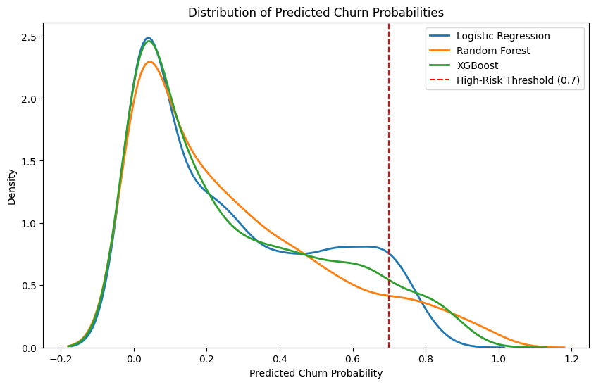

```python
import matplotlib.pyplot as plt
import seaborn as sns
import pandas as pd

# Create a DataFrame to store probabilities from all three models
prob_df = pd.DataFrame({
    "Logistic Regression": churn_probs,
    "Random Forest": churn_probs_rf,
    "XGBoost": churn_probs_xgb
})

# Set plot style
plt.figure(figsize=(10, 6))

# Plot density curves for each model
sns.kdeplot(prob_df["Logistic Regression"], label="Logistic Regression", linewidth=2)
sns.kdeplot(prob_df["Random Forest"], label="Random Forest", linewidth=2)
sns.kdeplot(prob_df["XGBoost"], label="XGBoost", linewidth=2)

# Add threshold line at 0.7 to indicate high-risk cutoff
plt.axvline(0.7, color='red', linestyle='dashed', label="High-Risk Threshold (0.7)")

# Customize labels and title
plt.xlabel("Predicted Churn Probability")
plt.ylabel("Density")
plt.title("Distribution of Predicted Churn Probabilities")
plt.legend()

plt.savefig("grafico12.png", dpi=300)  # Guardar imagen en alta calidad

plt.show()
```

At first glance, it seems contradictory that Logistic Regression has a higher density around 0.7 - 0.76 but a lower percentage (6.53%) of customers classified as high-risk (probability > 0.7) compared to Random Forest and XGBoost, which had over 8%. However, we need to keep in mind a few key aspects:

- Density plots show concentration, not absolute counts.
  - Logistic Regression’s peak in the 0.7 - 0.76 range suggests that customers are tightly grouped around this probability.
  - However, this does not mean there are more customers overall above 0.7.
- As Logistic Regression's curve drops sharply after 0.76, fewer customers exceed 0.7 in total.
  - The percentage of high-risk customers is based on how many exceed 0.7, not just how many are near it.
- Random Forest & XGBoost may have a broader distribution.
  - Their probabilities might spread more evenly above 0.7, leading to more total customers classified as high-risk.

We can plot a boxplot of the churn probabilities for each model or analyze the distribution with statistics like the 75th and 90th percentile to see how well the models predict high probabilities.

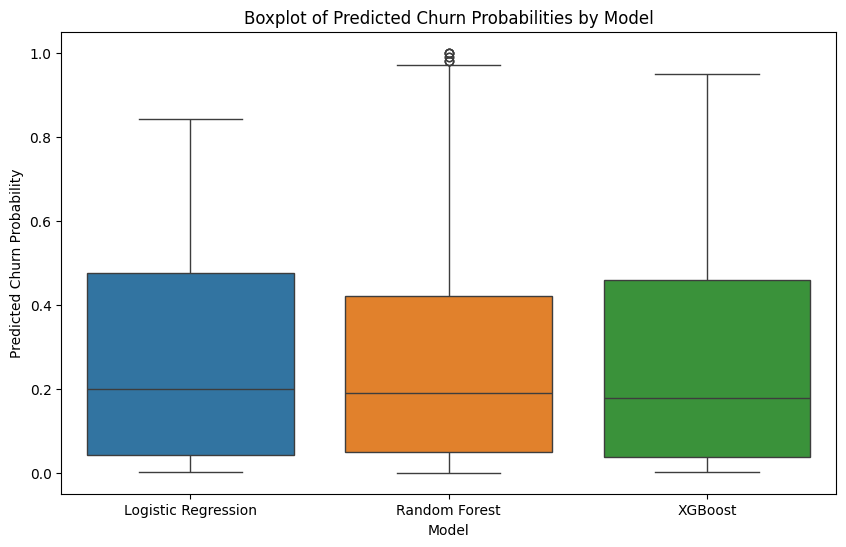

```python
import matplotlib.pyplot as plt
import seaborn as sns
import pandas as pd

# Create a DataFrame to store churn probabilities from all models
prob_df = pd.DataFrame({
    "Logistic Regression": churn_probs,
    "Random Forest": churn_probs_rf,
    "XGBoost": churn_probs_xgb
})

# Set plot style
plt.figure(figsize=(10, 6))
sns.boxplot(data=prob_df)

# Customize labels and title
plt.xlabel("Model")
plt.ylabel("Predicted Churn Probability")
plt.title("Boxplot of Predicted Churn Probabilities by Model")

plt.savefig("grafico13.png", dpi=300)  # Guardar imagen en alta calidad

# Show plot
plt.show()
```

**How to Interpret the Boxplot?**

- Median line: Shows the central tendency of churn probabilities.
- Interquartile range (IQR): Tells us how spread out the probabilities are.
- Whiskers: Show the range of typical values, while outliers appear as individual points.

**Interpretation**

- Since Logistic Regression has a shorter whisker and no high outliers, it confirms that fewer customers are predicted with probabilities greater than 0.7, despite the density peak.
- In contrast, Random Forest and XGBoost have longer whiskers, indicating that they distribute more customers above 0.7, which explains why their high-risk percentages are larger.

### Feature Importance Across Models

[output not shown]

**Insights from Feature Importance:**

- XGBoost & Random Forest agree on key features (Contract Type, Fiber Optic, Payment Method).
- Logistic Regression provides directionality (positive or negative effects).
- A combination of Logistic Regression & Tree-based models provides the best insights.

### Final Recommendations for Churn Prevention

#### Using Model Insights for Business Decisions:

- **Encourage Long-Term Contracts:** Since contract type **strongly reduces churn**, offering discounts for 1-year and 2-year plans could improve retention.
- **Improve Service for Fiber Optic Users:** Since these customers have **higher churn risk**, **service quality improvements** or **price adjustments** may help.
- **Target High Monthly Charge Customers:** These users are **more likely to leave**, so offering personalized retention offers may prevent churn.
- **Reduce Reliance on Electronic Check Payments:** Customers paying this way churn more. **Encouraging automatic payments (credit card/bank transfer) might help.**

#### Final Thoughts

🔹 **No single model is perfect** → A hybrid approach could work best!  
🔹 **Combining insights from Logistic Regression & XGBoost** allows for **both interpretability & predictive power**.  
🔹 **Adjusting the decision threshold** (e.g., 0.4 instead of 0.5) **significantly improves recall at the cost of false positives**.